# Parkinson’s Disease Research Program

BIOL90042 Final Project

Author

Group 7

Published

October 23, 2026

# 1 AI Declaration

## 1.1 Jesamine Newman

### 1.1.1 Acknowledgement

I acknowledge the use of Claude (https://claude.ai/) to explore published precedents for interpreting simulated gait measurements and selecting descriptive statistics, and to seek suggestions for transformations of the clinical-trial outcome variable.

### 1.1.2 Program/app/service used

Claude — Sonnet 5.5 Medium (as recorded by the student).

### 1.1.3 Prompts used and use of outputs

**Prompt 1: Gait measurements and descriptive statistics**

> I have an assignment to analyse fake clinical trial data from a Parkinson’s trial. For each participant (new drug or SOC), vertical orientation (degrees off-axis, presumably meaning straight upright) was measured every second while walking.

> Firstly, plotting each patient’s orientation over time shows a very zig-zagging line. maximum orientation off-axis can range from absolute values of 10 to 60 degrees, and change from negative to positive very often (many times within a minute). Is this a realistic representation of a parkinson’s patient’s gait? Has this kind of measurement been used in any studies?

> Second, I need to choose a descriptive statistic of each patient’s orientation data over time to represent their balance/gait smoothness. Possibilities for this would include standard deviation, range, iqr, mean absolute value, and median absolute value. are any of these standard for use in parkinson’s studies? or for measuring other clinical data that oscillates over time?

Use: I used the output to explore whether comparable gait measurements and descriptive statistics had precedents in published research. I did not ask Claude to select the statistic for the analysis. I also independently consulted the literature to inform this decision.

#### 1.1.3.1 Prompt 2: Exploring transformations

> these are qq plots for my outcome variable for two groups against the normal distribution. can you tell me which transformation might best make the data normal? I have tried many but most make either one or both groups worse

Additional input: I supplied an image of the Q–Q plots containing the points and reference lines, without axis labels.

Use: I used the output to explore possible transformations of the outcome variable when assessing the normality assumption.

### 1.1.4 Additional program/app/service used

Google AI Overviews, accessed through Google Search (https://www.google.com/).

### 1.1.5 Prompt and use of output

Search query: I searched Google for an error encountered during the analysis. An AI Overview appeared in the search results.

Use: I consulted the AI-generated overview as part of troubleshooting the error.

## 1.2 Tushar Raja

### 1.2.1 Acknowledgement

I acknowledge the use of Perplexity (https://www.perplexity.ai/) to assist with Quarto troubleshooting and provide guidance on GitHub collaboration during the preparation of this assessment.

### 1.2.2 Program/app/service used

Perplexity AI.

### 1.2.3 Prompts used and use of outputs

#### 1.2.3.1 Quarto troubleshooting

I supplied the Quarto rendering log containing the following error:

> error in evaluating the argument ‘object’ in selecting a method for function ‘coef’: object ‘row_model’ not found

I subsequently supplied the same error again to request further troubleshooting.

Use: I used the output to help identify the cause of the rendering error and obtain guidance on defining the required model objects before they were referenced in the document.

#### 1.2.3.2 GitHub and collaborative editing

I entered the following prompts:

> pull file from github repo rstudio qmd that i’ve pushed but i’m editing with others

Follow-up:

> i dont have updated version from github

Follow-up:

> how to bring this file to branch

I also supplied Git error messages concerning:

- Uncommitted changes preventing a branch switch.
- An untracked project file preventing a pull.
- A rejected push requiring remote changes to be integrated.

Use: I used the outputs as procedural guidance for retrieving collaborators’ updates, moving a file between branches, preserving local changes, and addressing Git errors during collaborative editing.

# 2 Project overview

Parkinson’s disease (PD) is a neurodegenerative disease involving the loss of dopamine-producing neurons in the substantia nigra of the brain. The resulting reduction in dopamine production causes motor symptoms, such as tremor, bradykinesia (slow movement) and an unsteady gait, as well as various non-motor symptoms. The causes of PD are not well-understood, and the current standard of care is the dopamine-replacement therapy L-DOPA, which helps to manage the motor symptoms of PD.

This report analyses four connected arms of a simulated PD research program: population genetics, RNA sequencing of patient-derived neurons, drug screening, and a clinical trial.

The report uses one visual language throughout:

- **Blue** represents healthy controls, matched controls, or L-DOPA control.
- **Orange** represents PD cases, test compounds, or the new compound.
- **Green** highlights statistically supported results or exercise.
- **Grey** represents background or non-significant observations.

# 3 Shared setup

```r
install.packages(c(
  "tidyverse",
  "pheatmap",
  "rstatix",
  "ggrepel",
  "broom",
  "patchwork",
  "ggbeeswarm",
  "knitr"
), repos = "https://cloud.r-project.org")
if (!requireNamespace("BiocManager", quietly = TRUE)) {
  install.packages("BiocManager", repos = "https://cloud.r-project.org")
}

BiocManager::install(c("edgeR", "limma"), ask = FALSE, update = FALSE)
# Load packages
library(tidyverse)
library(RNAseq123)
library(pheatmap)
library(ggrepel)
library(broom)
library(patchwork)
library(ggbeeswarm)
library(knitr)
library(rstatix)

# Load every dataset once from paths relative to the R project root.
load("data/prs.Rda")
load("data/rnaseq.Rda")
load("data/rnaseq_gene_info.Rda")
load("data/drugscreen.Rda")
load("data/gait.Rda")

# Use one semantic, colour-blind-friendly palette throughout the report.
control_colour <- "#0072B2"
case_colour <- "#D55E00"
support_colour <- "#009E73"
neutral_colour <- "#8C8C8C"
down_colour <- "#1a0099"
up_colour <- "#990000"

status_colours <- c("ctrl" = control_colour, "case" = case_colour)
group_colours <- c("control" = control_colour, "case" = case_colour)
treatment_colours <- c("L-DOPA control" = control_colour,
                       "New compound" = case_colour)
exercise_colours <- c("n" = neutral_colour, "y" = support_colour)
scale_cols <- c( "Not DE" = neutral_colour,"Lower in PD" = down_colour, "Higher in PD" = up_colour)


# Apply readable typography and layout to all ggplot figures.
theme_set(
  theme_classic(base_size = 13) +
    theme(
      plot.title = element_text(face = "bold"),
      legend.position = "bottom",
      strip.background = element_rect(fill = "white", colour = "grey70"),
      strip.text = element_text(face = "bold")
    )
)
```

# 4 Population genetics

## 4.1 Introduction

### 4.1.1 Background

A polygenic risk score (PRS) combines information from multiple genetic variants to summarise genetic predisposition to a disease. A higher PRS indicates a higher relative genetic risk of Parkinson’s disease (PD) based on the variants included in the score, but it does not determine whether an individual will develop PD.

This analysis used genotype data from 15 genetic loci and GWAS beta values. For each locus, the allele dosage (0, 1 or 2) was multiplied by its beta value. These values were then added together to calculate a PRS for each participant.

### 4.1.2 Aims

1. Calculate a PRS for each participant and identify the highest and lowest scores.
2. Compare the PRS distributions between PD cases and healthy controls.
3. Test whether there is a statistically significant difference in mean PRS between the two groups.

## 4.2 Question 1: Step1-Step6

*Calculate a PRS for each participant. Which participant has the highest PRS? The lowest?*

### 4.2.1 Step 1: Inspect the genotype and GWAS datasets

Check the two datasets. Make sure the locus names can be matched.

```r
## Check the participant genotype data.
ca_co_genotypes
```

| donorid | status | locus_1_A_T | locus_2_T_A | locus_3_A_T | locus_4_T_A | locus_5_T_G | locus_6_G_T | locus_7_C_T | locus_8_G_A | locus_9_A_T | locus_10_A_G | locus_11_A_T | locus_12_G_T | locus_13_C_T | locus_14_G_A | locus_15_G_A |
| --- | --- | --- | --- | --- | --- | --- | --- | --- | --- | --- | --- | --- | --- | --- | --- | --- |
| d001 | case | 0 | 0 | 0 | 0 | 0 | 0 | 0 | 1 | 1 | 1 | 0 | 0 | 1 | 1 | 1 |
| d002 | ctrl | 1 | 0 | 1 | 0 | 0 | 0 | 0 | 0 | 1 | 0 | 1 | 0 | 1 | 1 | 0 |
| d003 | case | 1 | 0 | 1 | 0 | 1 | 2 | 1 | 1 | 0 | 2 | 0 | 2 | 1 | 2 | 0 |
| d004 | ctrl | 0 | 0 | 0 | 0 | 0 | 0 | 0 | 1 | 0 | 0 | 0 | 0 | 1 | 1 | 0 |
| d005 | ctrl | 0 | 0 | 1 | 0 | 0 | 0 | 0 | 1 | 0 | 0 | 1 | 1 | 0 | 0 | 0 |
| d006 | ctrl | 1 | 0 | 1 | 0 | 0 | 0 | 0 | 0 | 1 | 0 | 0 | 0 | 1 | 1 | 0 |
| d007 | case | 0 | 1 | 0 | 1 | 0 | 0 | 0 | 1 | 2 | 0 | 1 | 0 | 0 | 1 | 0 |
| d008 | ctrl | 0 | 0 | 1 | 0 | 0 | 0 | 0 | 0 | 0 | 0 | 0 | 1 | 1 | 0 | 1 |
| d009 | ctrl | 0 | 0 | 1 | 0 | 0 | 0 | 0 | 0 | 0 | 1 | 1 | 1 | 0 | 2 | 0 |
| d010 | case | 1 | 2 | 0 | 0 | 0 | 0 | 0 | 2 | 0 | 0 | 2 | 0 | 0 | 1 | 1 |

[output cut: 290 more lines]

```r
## Check the GWAS beta values.
gwas_top_hits
```

| locus | ref | alt | beta | maf | se | pval |
| --- | --- | --- | --- | --- | --- | --- |
| locus_1_A_T | A | T | 0.233 | 0.130 | 0.0297 | 4.00e-15 |
| locus_2_T_A | T | A | 0.157 | 0.232 | 0.0237 | 2.91e-11 |
| locus_3_A_T | A | T | 0.163 | 0.249 | 0.0231 | 1.76e-12 |
| locus_4_T_A | T | A | 0.244 | 0.101 | 0.0332 | 1.95e-13 |
| locus_5_T_G | T | G | 0.228 | 0.129 | 0.0299 | 2.22e-14 |
| locus_6_G_T | G | T | 0.222 | 0.129 | 0.0298 | 1.01e-13 |
| locus_7_C_T | C | T | 0.249 | 0.109 | 0.0320 | 8.66e-15 |
| locus_8_G_A | G | A | 0.183 | 0.160 | 0.0273 | 2.24e-11 |
| locus_9_A_T | A | T | 0.165 | 0.296 | 0.0219 | 5.75e-14 |
| locus_10_A_G | A | G | 0.240 | 0.126 | 0.0302 | 1.55e-15 |

[output cut: 5 more lines]

**Result interpretation:**

The analysis uses 15 genetic loci with their corresponding GWAS beta values. Each locus is identified by a code in the dataset. These beta values are used to calculate the PRS for each participant.

### 4.2.2 Step 2: Reshape the genotype data

The genotype dataset is reshaped from wide to long format so each participant–locus combination has its own row.

```r
## Change the genotype data from wide to long format.
prs_long <- ca_co_genotypes %>%
  pivot_longer(
    # Select the 15 locus columns.
    cols = starts_with("locus_"),
    # Create a column for locus names.
    names_to = "locus",
    # Create a column for allele dosage.
    values_to = "dosage"
    )
```

```r
## Check the new data format.
prs_long
```

| donorid | status | locus | dosage |
| --- | --- | --- | --- |
| d001 | case | locus_1_A_T | 0 |
| d001 | case | locus_2_T_A | 0 |
| d001 | case | locus_3_A_T | 0 |
| d001 | case | locus_4_T_A | 0 |
| d001 | case | locus_5_T_G | 0 |
| d001 | case | locus_6_G_T | 0 |
| d001 | case | locus_7_C_T | 0 |
| d001 | case | locus_8_G_A | 1 |
| d001 | case | locus_9_A_T | 1 |
| d001 | case | locus_10_A_G | 1 |

[output cut: 4490 more lines]

### 4.2.3 Step 3: Add the GWAS beta values

Match the locus identifiers between the genotype and GWAS datasets, then confirm that each genotype record has a beta coefficient.

```r
## Add GWAS beta values to the genotype data.
prs_long_new <- prs_long %>%
  left_join(
    # Keep locus and beta.
    gwas_top_hits %>% dplyr::select(locus, beta),
    # Match using the locus name.
    by = "locus"
  )
```

```r
## Check for missing beta values after joining the datasets.
prs_long_new %>%
  summarise(missing_beta = sum(is.na(beta)))
```

| missing_beta |
| --- |
| 0 |

**Result interpretation:**

A result of 0 means there are no missing beta values in prs_long_new. Every row has a beta value, so the dataset is ready for the next step of PRS calculation.

```r
## Check the joined data.
prs_long_new
```

| donorid | status | locus | dosage | beta |
| --- | --- | --- | --- | --- |
| d001 | case | locus_1_A_T | 0 | 0.233 |
| d001 | case | locus_2_T_A | 0 | 0.157 |
| d001 | case | locus_3_A_T | 0 | 0.163 |
| d001 | case | locus_4_T_A | 0 | 0.244 |
| d001 | case | locus_5_T_G | 0 | 0.228 |
| d001 | case | locus_6_G_T | 0 | 0.222 |
| d001 | case | locus_7_C_T | 0 | 0.249 |
| d001 | case | locus_8_G_A | 1 | 0.183 |
| d001 | case | locus_9_A_T | 1 | 0.165 |
| d001 | case | locus_10_A_G | 1 | 0.240 |

[output cut: 4490 more lines]

### 4.2.4 Step 4: Calculate the score for each locus

The contribution of each locus is its allele dosage multiplied by the corresponding GWAS beta coefficient.

```r
## Dosage is coded as 0, 1 or 2 for each locus.
## Multiply the dosage by the GWAS beta value.
prs_weighted <- prs_long_new %>%
  # Calculate the weighted score for each locus.
  mutate(weighted_risk = dosage * beta)
```

```r
## Check the weighted scores.
prs_weighted
```

| donorid | status | locus | dosage | beta | weighted_risk |
| --- | --- | --- | --- | --- | --- |
| d001 | case | locus_1_A_T | 0 | 0.233 | 0.000 |
| d001 | case | locus_2_T_A | 0 | 0.157 | 0.000 |
| d001 | case | locus_3_A_T | 0 | 0.163 | 0.000 |
| d001 | case | locus_4_T_A | 0 | 0.244 | 0.000 |
| d001 | case | locus_5_T_G | 0 | 0.228 | 0.000 |
| d001 | case | locus_6_G_T | 0 | 0.222 | 0.000 |
| d001 | case | locus_7_C_T | 0 | 0.249 | 0.000 |
| d001 | case | locus_8_G_A | 1 | 0.183 | 0.183 |
| d001 | case | locus_9_A_T | 1 | 0.165 | 0.165 |
| d001 | case | locus_10_A_G | 1 | 0.240 | 0.240 |

[output cut: 4490 more lines]

### 4.2.5 Step 5: Calculate one PRS per participant

Add the 15 weighted locus contributions within each participant to obtain the total PRS.

```r
## Add the weighted scores across all 15 loci.
## Use the weighted data.
prs_final <- prs_weighted %>%
  summarise(
    PRS = sum(weighted_risk),
    .by = c(donorid, status)
  )
```

```r
## Check the final PRS data.
prs_final
```

| donorid | status | PRS |
| --- | --- | --- |
| d001 | case | 1.140 |
| d002 | ctrl | 1.073 |
| d003 | case | 2.824 |
| d004 | ctrl | 0.529 |
| d005 | ctrl | 0.686 |
| d006 | ctrl | 0.907 |
| d007 | case | 1.230 |
| d008 | ctrl | 0.739 |
| d009 | ctrl | 1.043 |
| d010 | case | 1.601 |

[output cut: 290 more lines]

```r
## Count the number of rows in the final PRS dataset.
nrow(prs_final)
```

```
[1] 300
```

**Result interpretation:**

The dataset contains 300 participants, with one PRS calculated for each participant.

### 4.2.6 Step 6: Find the highest and lowest PRS

#### 4.2.6.1 6A: The Highest PRS

```r
## Find the participant with the highest PRS.
prs_highest <- prs_final %>%
  # Keep one highest value.
  slice_max(PRS, n = 1, with_ties = FALSE)
```

```r
## Show the highest PRS.
prs_highest
```

| donorid | status | PRS |
| --- | --- | --- |
| d003 | case | 2.824 |

#### 4.2.6.2 6B: The Lowest PRS

```r
## Find the participant with the lowest PRS.
prs_lowest <- prs_final %>%
  # Keep one lowest value.
  slice_min(PRS, n = 1, with_ties = FALSE)
```

```r
## Show the lowest PRS.
prs_lowest
```

| donorid | status | PRS |
| --- | --- | --- |
| d167 | case | 0.157 |

**Result interpretation:**

Participant d003 (PD case) had the highest PRS (2.824), while participant d167 (PD case) had the lowest PRS (0.157).

## 4.3 Question 2: Step7-Step8

*Plot and describe the distribution of PRS for both cases and controls.*

### 4.3.1 Step 7: Calculate PRS Descriptive Statistics for Case and Control Groups

Calculate the sample size, mean, median, standard deviation and range of PRS separately for the two groups.

```r
## Use the final PRS data to calculate summary statistics.
prs_summary <- prs_final %>%
  # Divide participants into groups based on their status.
  group_by(status) %>%
  # Calculate the following statistics for each group.
  summarise(
    n = n(),                # Count the number of participants in each group.
    mean = mean(PRS),       # Calculate the average PRS for each group.
    median = median(PRS),   # Find the middle PRS value in each group.
    sd = sd(PRS),           # Calculate how much PRS values vary within each group.
    min = min(PRS),         # Find the lowest PRS value in each group.
    max = max(PRS)          # Find the highest PRS value in each group.
  ) %>%
  # Remove all remaining grouping.
  ungroup()
```

```r
## Display the summary statistics for the case and control groups.
prs_summary
```

| status | n | mean | median | sd | min | max |
| --- | --- | --- | --- | --- | --- | --- |
| case | 150 | 1.1923333 | 1.171 | 0.4517814 | 0.157 | 2.824 |
| ctrl | 150 | 0.8870733 | 0.868 | 0.3573128 | 0.307 | 1.979 |

**Result interpretation:**

The case and control groups each had 150 participants.

The case group had a higher mean PRS (1.192) than the control group (0.887). The median PRS was also higher in the case group (1.171) than in the control group (0.868).

The case group had a higher standard deviation (0.452) than the control group (0.357), indicating greater variation in PRS values.

The PRS ranged from 0.157 to 2.824 in the case group and from 0.307 to 1.979 in the control group.

The higher average PRS among cases is consistent with a greater burden of the weighted PD-associated genetic effects included in this score. However, these descriptive differences do not alone establish statistical significance or allow reliable individual diagnosis.

### 4.3.2 Step 8: Visualise and Compare PRS Distributions Between Case and Control Groups

#### 4.3.2.1 8A: Create Histograms to Compare PRS Distributions

Histograms show the shape, spread and skewness of PRS distributions.

```r
## Use histograms to examine the distribution of PRS in each group.
## Histograms help show the shape, spread, and possible skewness of the data.
prs_histogram <- ggplot(prs_final, aes(x = PRS, fill = status)) +
  geom_histogram(bins = 18, colour = "white", alpha = 0.9) +
  # Create separate histograms for the case and control groups.
  # This makes it easier to examine the distribution in each group.
  facet_wrap(~ status) +
  scale_fill_manual(values = status_colours) +
  labs(title = "Distribution of Polygenic Risk Scores",
       x = "Polygenic Risk Score (PRS)",
       y = "Number of participants") +
  theme_classic(base_size = 13) +
  theme(legend.position = "none")
```

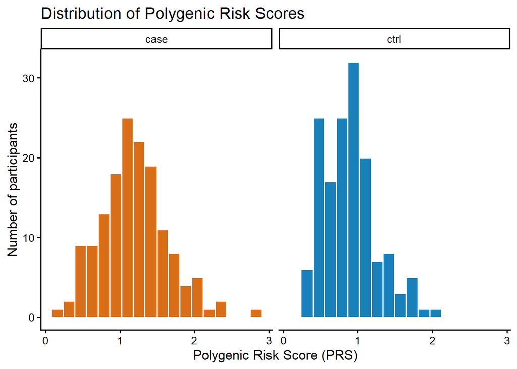

```r
## Display the histograms for the case and control groups.
prs_histogram
```

**Result interpretation:**

Step 8A: Histogram

Both histograms show a single main peak and some right skew, with greater right skew in controls.

The case distribution extends across a wider PRS range and is shifted towards higher values, although the two groups overlap.

This is consistent with higher relative genetic predisposition among PD cases as measured by this PRS.

#### 4.3.2.2 8B: Create a Boxplot to Compare PRS Distributions

A boxplot makes it easier to compare medians, variability and potential outliers.

```r
## Use a boxplot to compare PRS values between the case and control groups.
## Boxplots show the median, spread, and possible outliers in each group.

prs_boxplot <- ggplot(
  prs_final,
  aes(x = status, y = PRS, fill = status)
) +
  geom_boxplot(
    width = 0.6,
    alpha = 0.9
  ) +
  scale_fill_manual(values = status_colours) +
  scale_y_continuous(
    limits = c(0, NA),
    expand = expansion(mult = c(0, 0.05))
  ) +
  labs(
    title = "PRS in Cases and Controls",
    x = "Disease status",
    y = "Polygenic Risk Score (PRS)"
  ) +
  theme_classic(base_size = 13) +
  theme(legend.position = "none")
```

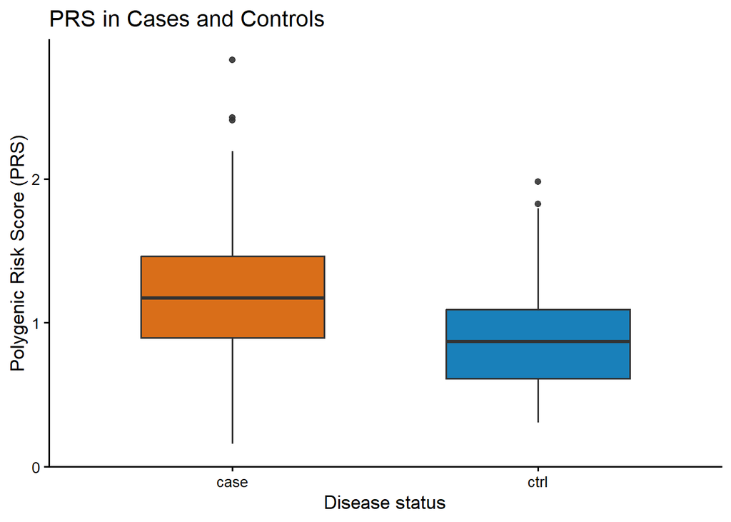

```r
## Display the boxplot to compare PRS between the two groups.
prs_boxplot
```

**Result interpretation:**

Step 8B: Boxplot

PD cases had a higher median PRS (1.171) than controls (0.868) and greater variability (SD 0.452 versus 0.357).

The analysis identified three high-PRS boxplot outliers among cases and two among controls.

The distributions still overlap, so the observed differences represent group-level patterns rather than a diagnostic threshold.

## 4.4 Question 3: Step 9 - Step 14

*Is there a statistically significant difference in the PRS of cases and controls? Ensure you check all the assumptions of the test you choose.*

### 4.4.1 Step 9: State the hypotheses

The main analysis uses Welch’s two-sample t-test to compare group mean PRS values. This test does not assume equal population variances. The hypotheses below apply to the difference in means tested by Welch’s t-test.

- **Null hypothesis (H0)**: The population mean PRS is equal in PD cases and healthy controls.
- **Alternative hypothesis (H1)**: The population mean PRS differs between PD cases and healthy controls.
- **Significance level**: α = 0.05, using a two-sided test.

### 4.4.2 Step 10: Assess the Assumptions of Welch’s t-test

**Data type**: PRS is a numerical outcome, and disease status defines two groups (PD cases and healthy controls).

**Independence**: Each participant contributes one PRS value. The source file does not establish whether participants are related or otherwise clustered, so full independence relies on the sampling design.

**Normality**: The relevant condition concerns the PRS distribution (or equivalently, within-group residual distribution) within each group, not the distribution of disease status. Q-Q plots and Shapiro–Wilk tests will assess this assumption.

With 150 participants per group, Welch’s t-test is reasonably robust to moderate deviations from normality, although strong outliers still merit attention.

**Equal variances**: Welch’s t-test does not require equal variances between groups. Group standard deviations and a residual plot will be used to examine differences in variability. Therefore, equal variances will not be assumed.

### 4.4.3 Step 11: Calculate fitted values and residuals

Residuals describe how far each PRS value is from its group’s mean, providing a way to compare the within-group spreads.

```r
## Calculate fitted values and residuals for each group.
prs_residuals <- prs_final %>%
  # Group by case or control.
  group_by(status) %>%
  mutate(
    # Use the group mean as the fitted value.
    fitted_PRS = mean(PRS),
    # Calculate observed minus fitted PRS.
    residual = PRS - fitted_PRS
  ) %>%
    # Remove grouping.
  ungroup()
```

```r
## Check the new columns.
prs_residuals
```

| donorid | status | PRS | fitted_PRS | residual |
| --- | --- | --- | --- | --- |
| d001 | case | 1.140 | 1.1923333 | -0.052333333 |
| d002 | ctrl | 1.073 | 0.8870733 | 0.185926667 |
| d003 | case | 2.824 | 1.1923333 | 1.631666667 |
| d004 | ctrl | 0.529 | 0.8870733 | -0.358073333 |
| d005 | ctrl | 0.686 | 0.8870733 | -0.201073333 |
| d006 | ctrl | 0.907 | 0.8870733 | 0.019926667 |
| d007 | case | 1.230 | 1.1923333 | 0.037666667 |
| d008 | ctrl | 0.739 | 0.8870733 | -0.148073333 |
| d009 | ctrl | 1.043 | 0.8870733 | 0.155926667 |
| d010 | case | 1.601 | 1.1923333 | 0.408666667 |

[output cut: 290 more lines]

### 4.4.4 Step 12: Check Normality of PRS in Each Group

#### 4.4.4.1 12A: Create Q-Q Plots to Check Normality

A Q-Q plot compares observed PRS quantiles with the quantiles expected under a normal distribution. If the points deviate from the reference line, especially at the tails, this suggests that the data may not be normally distributed.

```r
## Use Q-Q plots to check whether PRS is normally distributed.
## Compare the PRS distribution with a theoretical normal distribution.

prs_qqplot <- ggplot(prs_final, aes(sample = PRS, fill = status, colour = status)) +
  # Add Q-Q plot points.
  # Use smaller points with a darker outline in the same colour family.
  geom_qq(shape = 21, size = 2, stroke = 0.7) +
  geom_qq_line(colour = "black", linewidth = 0.8) +
  facet_wrap(~ status) +
  scale_fill_manual(values = status_colours) +
  scale_colour_manual(values = status_colours) +
  labs(
    title = "Q-Q Plots of PRS",
    x = "Theoretical Quantiles",
    y = "Sample Quantiles"
  ) +
  theme_classic(base_size = 13) +
  theme(legend.position = "none")
```

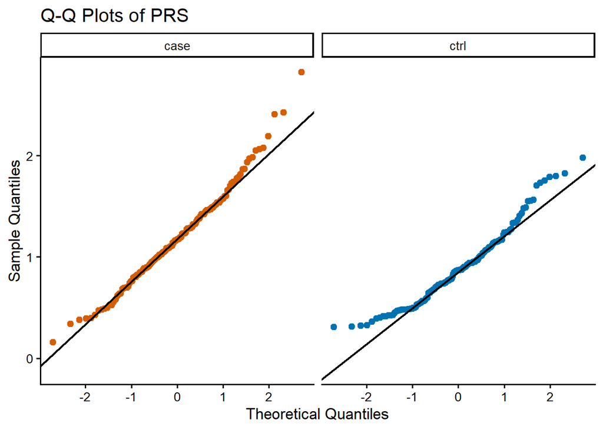

```r
## Display the Q-Q plots for both groups.
prs_qqplot
```

**Result interpretation:**

The Q-Q plots indicate that cases lie closer to the reference line, while controls show greater departures, especially in the upper tail.

This suggests that normality is less plausible for the control group.

The Shapiro–Wilk tests in Step 12B provide an additional quantitative check.

#### 4.4.4.2 12B: Use the Shapiro–Wilk Test to Check Normality

Use the Shapiro-Wilk test to check normality in each group.

A p-value below 0.05 suggests a significant departure from normality.

```r
## Check normality in the case group.
prs_final %>%
  # Select participants from the case group.
  filter(status == "case") %>%
  # Extract PRS values as a numeric vector.
  pull(PRS) %>%
  # Run the Shapiro-Wilk normality test.
  shapiro.test()
```

```
    Shapiro-Wilk normality test

data:  .
W = 0.98374, p-value = 0.07411
```

```r
## Check normality in the control group.
prs_final %>%
  # Select participants from the control group.
  filter(status == "ctrl") %>%
  # Extract PRS values as a numeric vector.
  pull(PRS) %>%
    # Run the Shapiro-Wilk normality test.
  shapiro.test()
```

```
    Shapiro-Wilk normality test

data:  .
W = 0.95683, p-value = 0.0001265
```

**Result interpretation:**

The Shapiro–Wilk test gave p-values of 0.074 for cases and 0.000127 for controls.

At α = 0.05, there is no statistically significant evidence of non-normality in cases, whereas controls show a significant departure from normality.

### 4.4.5 Step 13: Check the Spread of Residuals Between Groups

```r
## Create a residual plot to compare the spread of PRS between groups.
## This plot helps check whether the groups have similar variances.

prs_residual_plot <- ggplot(
  # Use the data containing fitted PRS values and residuals.
  prs_residuals,
  # Plot fitted PRS on the x-axis and residuals on the y-axis.
  # Use different colours for the case and control groups.
  aes(x = fitted_PRS, y = residual, fill = status, colour = status)
) +
  geom_jitter(width = 0.035, height = 0,
              shape = 21, size = 2, stroke = 0.5) +
  geom_hline(yintercept = 0, linetype = "dashed",
             colour = "black") +
  scale_fill_manual(values = status_colours) +
  scale_colour_manual(values = status_colours) +
  labs(
    title = "Residual Plot for PRS",
    x = "Fitted PRS",
    y = "Residual"
  ) +
  theme_classic(base_size = 13) +
  theme(legend.position = "none")
```

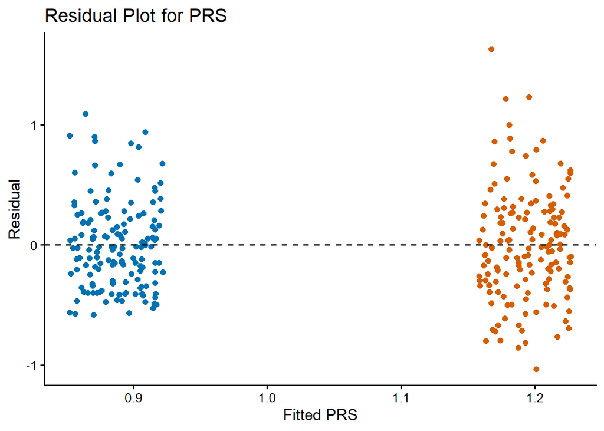

```r
## Display the residual plot for both groups.
prs_residual_plot
```

**Result interpretation:**

The case group had a higher SD (0.452) than the control group (0.357). The residual plot also suggested a wider spread in cases. Therefore, equal variances were not assumed. Welch’s t-test was selected because it does not require equal variances between groups.

### 4.4.6 Step 14: Run Statistical Tests to Compare PRS Between Groups

#### 4.4.6.1 14A: Wilcoxon Rank-Sum Test

```r
## Use the Wilcoxon rank-sum test to compare PRS between groups.
## This test does not require normally distributed data.
## It compares the groups using the ranks of PRS values.

prs_wilcox <- wilcox.test(
  # Compare PRS between case and control groups.
  PRS ~ status,
  # Use the final PRS dataset.
  data = prs_final
)
```

```r
## Display the test statistic and p-value.
prs_wilcox
```

```
    Wilcoxon rank sum test with continuity correction

data:  PRS by status
W = 15956, p-value = 3.746e-10
alternative hypothesis: true location shift is not equal to 0
```

**Result interpretation:**

The Wilcoxon rank-sum test showed a statistically significant difference in PRS between PD cases and controls (p < 0.001).

This result supports the finding that PRS values differ between the two groups. The test was used as a non-parametric check because the control group showed a significant departure from normality.

#### 4.4.6.2 14B: Welch’s t-test

```r
## Use Welch's t-test to compare mean PRS between groups.
## This test does not require equal variances.
## It is used as the main test for the difference in mean PRS.

prs_welch <- t.test(
   # Compare mean PRS between cases and controls.
  PRS ~ status,
   # Use the final PRS dataset.
  data = prs_final,
   # Use Welch's t-test, which allows different variances between groups.
  var.equal = FALSE
)
```

```r
## Display the t-statistic, p-value, and confidence interval.
prs_welch
```

```
    Welch Two Sample t-test

data:  PRS by status
t = 6.4907, df = 282.98, p-value = 3.816e-10
alternative hypothesis: true difference in means between group case and group ctrl is not equal to 0
95 percent confidence interval:
 0.2126862 0.3978338
sample estimates:
mean in group case mean in group ctrl
         1.1923333          0.8870733
```

**Result interpretation:**

Welch’s t-test was used as the main test to compare mean PRS between the two groups because it does not require equal variances. With 150 participants per group, it is also reasonably robust to moderate non-normality.

The test showed a statistically significant difference in mean PRS (t = 6.491, df = 282.98, p < 0.001).

The mean PRS was higher in PD cases (1.192) than controls (0.887). The mean difference was 0.305 (95% CI: 0.213–0.398).

Therefore, the null hypothesis of equal means was rejected. The higher mean PRS in PD cases is consistent with greater genetic predisposition to PD based on the variants included in this analysis.

### 4.4.7 Question 1.

*Calculate a PRS for each participant. Which participant has the highest PRS? The lowest?*

Polygenic risk scores (PRS) were calculated for 300 participants using 15 genetic loci. For each participant, the allele dosage (0, 1 or 2) at each locus was multiplied by its corresponding GWAS beta coefficient. The weighted values were then summed to calculate the total PRS.

Participant d003, a PD case, had the highest PRS (2.824). Participant d167, also a PD case, had the lowest PRS (0.157).

### 4.4.8 Question 2.

*Plot and describe (with descriptive statistics) the distribution of PRS for both cases and controls.*

Histograms and a boxplot were used to compare PRS distributions between PD cases and controls. Each group contained 150 participants.

PD cases had a higher mean PRS (1.192) than controls (0.887). The median was also higher in cases (1.171) than controls (0.868).

Cases had a higher standard deviation (0.452) than controls (0.357), indicating greater variation. PRS values ranged from 0.157 to 2.824 in cases and from 0.307 to 1.979 in controls.

Both distributions were right-skewed, with greater right skew in controls. The distributions also overlapped.

Overall, PD cases had higher PRS values and greater variation, suggesting greater genetic predisposition to PD based on the variants included in this analysis.

### 4.4.9 Question 3.

*Is there a statistically significant difference in the PRS of cases and controls? Ensure you check all the assumptions of the test you choose.*

The null hypothesis (H0) was that cases and controls had equal mean PRS. The alternative hypothesis (H1) was that their mean PRS differed.

Each participant had one PRS value, although independence between participants could not be fully confirmed from the dataset.

Normality was assessed using Q-Q plots and Shapiro–Wilk tests. Controls showed a significant departure from normality (p < 0.001), while cases showed no statistically significant departure from normality (p = 0.074).

The boxplot also identified potential outliers in both groups. These observations were retained in the analysis. The Wilcoxon rank-sum test was used as a supplementary rank-based comparison.

The residual plot and descriptive statistics suggested greater variation in cases than controls. Therefore, Welch’s t-test was selected because it does not require equal variances and is reasonably robust to moderate non-normality with 150 participants per group.

Welch’s t-test showed a statistically significant difference in mean PRS (t = 6.491, df = 282.98, p < 0.001). Cases had a higher mean PRS than controls, with a mean difference of 0.305 (95% CI: 0.213–0.398).

The Wilcoxon rank-sum test also showed a significant difference between the groups (p < 0.001).

Therefore, the null hypothesis was rejected. PD cases had a significantly higher mean PRS than controls, suggesting greater genetic predisposition to PD based on the variants included in this analysis. However, this association does not establish causation or determine an individual’s absolute risk of developing PD.

# 5 RNA-seq of patient iPSC-derived neurons

## 5.1 Introduction

Parkinson’s disease (PD) is a neurodegenerative disorder characterised by the progressive loss of dopaminergic neurons. This report analyses RNA sequencing data to compare the gene expression of PD neurons with that of healthy controls, using the `edgeR` and `limma` (voom) pipeline.

### 5.1.1 Background

To compare the transcriptional profiles of PD neurons with those of healthy controls, induced pluripotent stem cells (iPSCs) from 8 PD patients and 8 age- and sex-matched healthy controls were differentiated into dopaminergic neurons. After two weeks in culture, RNA was isolated, sequenced and pre-processed to produce a count matrix for 10,100 genes across 16 samples.

### 5.1.2 Aims

The aim of this report is to characterise the transcriptional differences between Parkinson’s disease (PD) and healthy control dopaminergic neurons. This analysis aims to:

1. Identify genes that are differentially expressed between PD cases and healthy controls, and visualise the results using MA and volcano plots.
2. Identify the Gene Ontology (GO) categories associated with the differentially expressed genes.
3. Assess whether samples cluster according to disease status.

## 5.2 Code and Interpretation

### 5.2.1 Checking the Datasets

```r
# 1. Inspecting the DGE list and understanding the data structure before analysis
head(dge$samples) # Sample metadata: group, library size, normalisation factor and donor id
```

|  | group | lib.size | norm.factors | donorid |
| --- | --- | --- | --- | --- |
| control1 | control | 32105738 | 1 | d102 |
| control2 | control | 29932424 | 1 | d035 |
| control3 | control | 29997110 | 1 | d259 |
| control4 | control | 19125948 | 1 | d199 |
| control5 | control | 18254696 | 1 | d125 |
| control6 | control | 22167001 | 1 | d225 |

```r
head(dge$genes) # Displays genes
```

|  | genes |
| --- | --- |
| 94027 | 94027 |
| 91978 | 91978 |
| 100616415 | 100616415 |
| 105370854 | 105370854 |
| 102723778 | 102723778 |
| 26082 | 26082 |

```r
head(dge$counts) # Determining raw read counts in the dataset (rows = genes, columns = samples)
```

```
          control1 control2 control3 control4 control5 control6 control7
94027         1913       35      122        5       19        7      365
91978          584      516      837      408      320     1229      462
100616415     1099     1005      312      410      661      122      677
105370854     1336      548      654      445      584      574      841
102723778      110      635     1303      430      564      744      830
26082          243      168      242      133       15      189      218
          control8 case1 case2 case3 case4 case5 case6 case7 case8
94027          551    62     0    24    85     7    17   206    32
91978         1160    22    16    73     3     8   265   460   652
100616415      849    35    65   190   123   100  1256  1379   371
105370854      660  1067  1502  3999   864  1271   279  3800   796
102723778      974   379   215   190    96   265  1096  1835   785
26082          481     2     0     2     4     1   499   515   277
```

```r
# 2. Checking how the experimental groups are coded
dge$samples$group
```

```
 [1] control control control control control control control control case
[10] case    case    case    case    case    case    case
Levels: control case
```

```r
class(dge$samples$group) #Stored as factors, needed for building the design matrix
```

```
[1] "factor"
```

```r
# 3. Set the reference level of the group factor
# Specifying the order of the levels, setting the 'control' group as the first(reference) level of the group factor to ensure accurate downstream analysis and plotting
dge$samples$group <- factor(dge$samples$group, levels = c("control", "case"))
# By putting control first, model coefficients and contrasts are interpreted relative to the control, e.g. positive logFC = higher expression in PD cases
levels(dge$samples$group) # Optional check: print "contro" "case"
```

```
[1] "control" "case"
```

### 5.2.2 The RNA Sequencing Pipeline

### 5.2.3 Filtering low count genes

Filtering out lowly expressed genes to ensure reliable testing as gene with low counts carry little information for detecting differential expression

```r
keep <- filterByExpr(dge) # Identifies genes with sufficient expression

# Using table() to create a summary to determine how many genes we will keep
table(keep)
```

```
keep
FALSE  TRUE
  204  9896
```

```r
# The number that fall within TRUE we will keep and FALSE will be genes filtered out and removed for analysis.

proportions(table(keep)) # The same summary as proportions, to show the fraction of genes removed and retained.
```

```
keep
     FALSE       TRUE
0.02019802 0.97980198
```

```r
# Subset the data to the DGEList
dge <- dge[keep, , keep.lib.sizes = FALSE] #Recalculates library size from the retained genes

# Checking the dimensions of the count matrix after filtering to see if the number of genes have been reduced
dim(dge$counts)
```

```
[1] 9896   16
```

Upon filtering, we can see that there is a reduced dimension count from 10100 16, now to 9896 16.

### 5.2.4 Normalisation

```r
#TMM (trimmed mean of M-values) corrects for differences in RNA composition between samples, reducing bias when comparing expression across samples
dge <- normLibSizes(dge, method = "TMM")

# Normalisation factors are then calculated for each sample and puts it in the samples dataframe of the DGE list
dge$samples # Library size and norm.factors for each sample
```

|  | group | lib.size | norm.factors | donorid |
| --- | --- | --- | --- | --- |
| control1 | control | 32094328 | 0.9959663 | d102 |
| control2 | control | 29924414 | 1.0212859 | d035 |
| control3 | control | 29990763 | 1.0271446 | d259 |
| control4 | control | 19119926 | 1.0238307 | d199 |
| control5 | control | 18249664 | 1.0337523 | d125 |
| control6 | control | 22159067 | 1.0210213 | d225 |
| control7 | control | 18170725 | 1.0243805 | d094 |
| control8 | control | 34446967 | 0.9941307 | d287 |
| case1 | case | 21499820 | 0.9630724 | d141 |
| case2 | case | 22690424 | 0.9595412 | d019 |

[output cut: 6 more lines]

```r
summary(dge$samples$norm.factors) # Distribution of the factors across samples
```

```
   Min. 1st Qu.  Median    Mean 3rd Qu.    Max.
 0.9595  0.9759  0.9990  1.0003  1.0219  1.0338
```

All normalisation factors are close to 1 across all samples, suggesting minimal differences in RNA composition between samples.

### 5.2.5 MDS plot

An MDS plot is conducted as a quality control step to check whether samples cluster by group, and look for potential outliers or unexpected patterns in the dataset, before modelling.

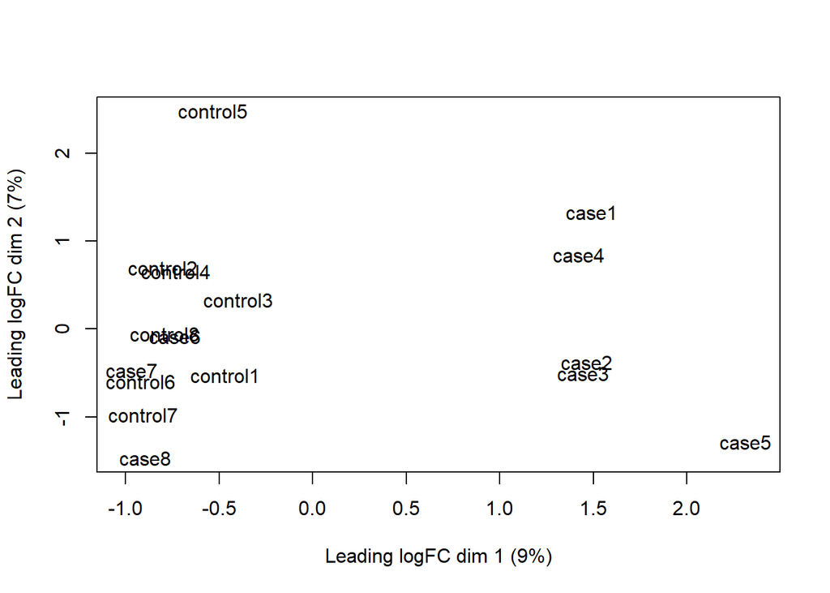

```r
#visualising our data prior to statistical testing
plotMDS(dge)
```

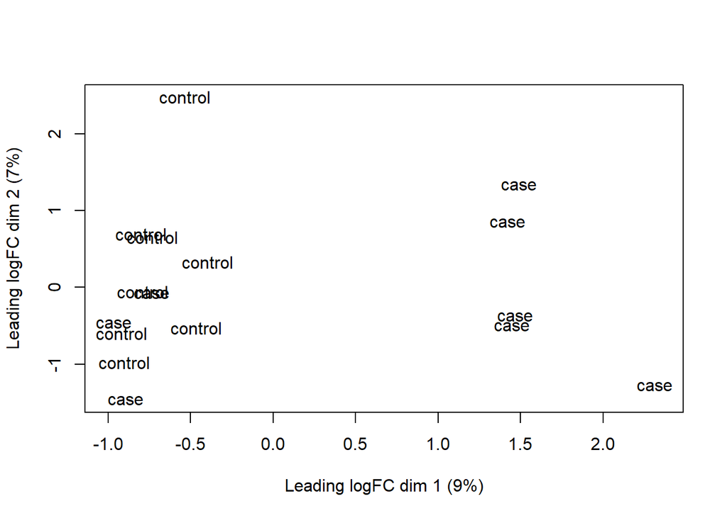

```r
# Specifying the name of the group the samples belong to by labelling
plotMDS(dge, labels = dge$samples$group)
```

Samples that appear closer together have more similar expression profiles, based on the leading log fold change distances used by plotMDS(). Cases 1 -5 cluster together being further apart than the controls samples and cases 6-8. This suggests their expression profiles are more variable within the group than the controls vs cases are from each other.

### 5.2.6 Setting up the Design Matrix

The design matrix specifies how each sample contributes to the linear model. We use a model without an intercept so that the control and case groups are represented by separate coefficients.

```r
# Build the design matrix from dge$sample as this contains all the sample metadata and covariates
design <- model.matrix(~ 0 + group, data = dge$samples) # The intercept is excluded so each coefficient is  the mean expression of one group (control and case). This makes the comparison amongst the two groups easy to specify.
design
```

```
         groupcontrol groupcase
control1            1         0
control2            1         0
control3            1         0
control4            1         0
control5            1         0
control6            1         0
control7            1         0
control8            1         0
case1               0         1
case2               0         1
case3               0         1
case4               0         1
case5               0         1
case6               0         1
case7               0         1
case8               0         1
attr(,"assign")
[1] 1 1
attr(,"contrasts")
attr(,"contrasts")$group
[1] "contr.treatment"
```

Output columns represent the groups, with the values being either 1 representing the sample being a member of either the control or case group or 0 in which the sample is not a member of that group.

### 5.2.7 Setting up the Contrasts Matrices

The contrast matrix defines the comparison of interest: PD cases minus healthy controls. Positive log₂ fold changes therefore indicate higher expression in PD cases, while negative values indicate lower expression.

```r
# Rename the columns of the design matrix to be just 'control' instead of 'groupcontrol'and likewise with 'groupcase' to be just 'case' for readability
colnames(design) <- c("control","case")

# Setting up the contrast matrix
contr_matrix <- makeContrasts(
  casevscontrol = "case - control",# Specify the name and formula for each specific contrast,  case - control, so positive logFC = higher in PD
  levels = design)

contr_matrix
```

```
         Contrasts
Levels    casevscontrol
  control            -1
  case                1
```

Output of this code will demonstrate that the case group will be equal to 1, while the control group will be equal to -1.

### 5.2.8 Adding genes name to the DGE list

The purpose of the following code is to add the respective gene names to the DGE list. It matches each gene’s Entrez ID in `dge$genes` to the lookup table `entrez_genename_key`, adds the gene name (renamed `SYMBOL`) and a description.

```r
# Joining gene names onto the Entrez IDs
gene_info <-
  dge$genes [, "genes", drop = FALSE] |>  # keeping only the Entrez ID column
  left_join( entrez_genename_key, # lookup table with gene names
  by =  join_by (genes == entrezid)) |>  # match genes in the left table to entrezid on the right
  dplyr::rename(SYMBOL = gene_name) # rename so the column is called SYMBOL

colnames(gene_info) # Expected: genes, SYMBOL, description
```

```
[1] "genes"       "SYMBOL"      "description"
```

```r
# Checking the join was reliable

# The join should not add or drop any genes, therfore every gene should be matched.
nrow(gene_info) == nrow(dge$counts)  # TRUE, the join didn't add or drop genes
```

```
[1] TRUE
```

```r
sum(is.na(gene_info$SYMBOL)) # 0, this shows that every gene was matched
```

```
[1] 0
```

```r
# Storing the annotation into the DGE list
rownames(gene_info) <- rownames(dge$counts) # join resets row names, put the IDs back
dge$genes <- gene_info # store the annotation into the dge list

head(dge$genes) # Check for genes, SYMBOL and description columns
```

|  | genes | SYMBOL | description |
| --- | --- | --- | --- |
| 94027 | 94027 | CGB7 | chorionic gonadotropin beta subunit 7 |
| 91978 | 91978 | TPGS1 | tubulin polyglutamylase complex subunit 1 |
| 100616415 | 100616415 | MIR4535 | microRNA 4535 |
| 105370854 | 105370854 | AC103740.1 | NULL |
| 102723778 | 102723778 | LINC02497 | NULL |
| 26082 | 26082 | LINC02249 | uncharacterized LOC26082 |

### 5.2.9 Variance Modelling with voom

The voom() function converts the filtered counts to log₂ counts per million (logCPM), using the library sizes and TMM normalisation factors calculated earlier. It also estimates how variability changes with expression level and assigns precision weights to account for these differences during linear modelling.

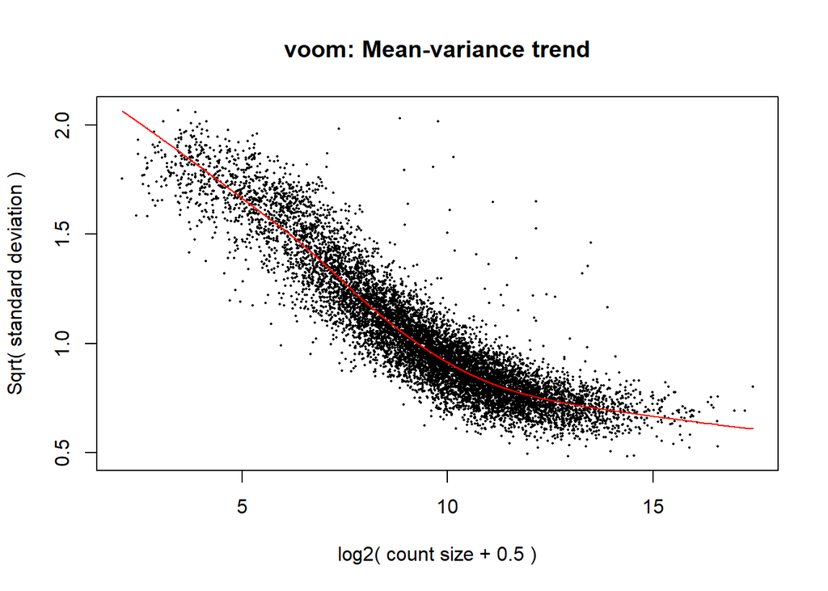

```r
# The voom function takes our DGElist object and design matrix as argument to produce the following plot.
v <- voom (dge, design, plot = TRUE)
```

The voom plot visualises the mean variance relationship with the x axis displaying the average log2 expression of each gene, alongside the y axis which shows the square root of the residual standard deviation of each gene.The mean-variance trend is overall smooth and decreasing, indicating that the precision weights are appropriate.

### 5.2.10 Fitting the Linear Model

After running voom, we fit a weighted linear model to each gene using the expression values and precision weights produced by voom(). We then apply the case-control contrast to estimate the log₂ fold change between PD cases and healthy controls.

```r
vfit <- lmFit(v)
head(vfit$coefficients) # Check coefficients
```

```
           control       case
94027     1.819611 -0.2351858
91978     4.627076  1.1047625
100616415 4.404643  3.0897015
105370854 4.696711  5.4787550
102723778 4.456473  3.8785977
26082     2.751941 -0.7723400
```

```r
# We can then use contrasts.fit() to calculate coefficients for each contrast of interest (case - control) specified in the contr_matrix.
vfit <- contrasts.fit(vfit, contrasts = contr_matrix) # Coefficients for case - control
head(vfit$coefficients)
```

```
           Contrasts
            casevscontrol
  94027        -2.0547965
  91978        -3.5223136
  100616415    -1.3149419
  105370854     0.7820444
  102723778    -0.5778749
  26082        -3.5242810
```

### 5.2.11 Statistical Testing

We apply empirical Bayes moderation to stabilise the gene-wise variance estimates by borrowing information across genes. This produces test statistics for the case-versus-control comparison. We then use decideTests() to classify genes as higher in PD, lower in PD, or not significantly different after multiple-testing correction.

```r
# Empirical Bayes moderation shrinks gene-wise variances towards the overall trend
efit <- eBayes(vfit)

# Classifying genes as down (-1), not significant (0) or up (1)
dt <- decideTests(efit) # Using decideTests to conduct for multiple testing
summary(dt)
```

```
       casevscontrol
Down              10
NotSig          9875
Up                11
```

### 5.2.12 Differential Expression Results Table

We use topTable() to extract the results for all tested genes, including gene annotations, log₂ fold changes, average expression, and raw and BH-adjusted p-values. By default, topTable() ranks genes by the B-statistic, which represents the log-odds of differential expression.

```r
# Using the function topTable() to obtain more information on the differentially expressed gene for contrast between control vs case group
top <- topTable(efit, coef = "casevscontrol", n = Inf)

# Convert to tibble, so its prints more neatly
top_tibble <- as_tibble(top)
top_tibble
```

| genes | SYMBOL | description | logFC | AveExpr | t | P.Value | adj.P.Val | B |
| --- | --- | --- | --- | --- | --- | --- | --- | --- |
| 6014 | RIT2 | Ras like without CAAX 2 | -4.377185e+00 | 5.3049451676 | -6.752173e+00 | 2.034311e-09 | 2.013154e-05 | 9.97826904 |
| 7405 | UVRAG | UV radiation resistance associated | 2.896011e+00 | 7.9163577462 | 6.397132e+00 | 9.621508e-09 | 4.331989e-05 | 9.77851306 |
| 8925 | HERC1 | HECT and RLD domain containing E3 ubiquitin protein ligase family member 1 | 3.090730e+00 | 8.5806524644 | 6.274624e+00 | 1.635838e-08 | 4.331989e-05 | 9.29713210 |
| 5594 | MAPK1 | mitogen-activated protein kinase 1 | -1.751070e+00 | 9.3869202863 | -6.144340e+00 | 2.866714e-08 | 5.673801e-05 | 8.76494848 |
| 9546 | APBA3 | amyloid beta precursor protein binding family A member 3 | -3.557994e+00 | 5.4804716331 | -6.258868e+00 | 1.751006e-08 | 4.331989e-05 | 8.58282408 |
| 1785 | DNM2 | dynamin 2 | 2.907779e+00 | 8.7109435564 | 5.737503e+00 | 1.611339e-07 | 2.657635e-04 | 7.13199046 |
| 5071 | PRKN | parkin RBR E3 ubiquitin protein ligase | 3.242619e+00 | 8.7894303145 | 5.625697e+00 | 2.570389e-07 | 3.633795e-04 | 6.69033683 |
| 345611 | IRGM | immunity related GTPase M | 4.084085e+00 | 7.4627020095 | 5.492555e+00 | 4.461689e-07 | 5.519109e-04 | 6.15146823 |
| 83933 | HDAC10 | histone deacetylase 10 | 3.313436e+00 | 6.9813984804 | 5.169585e+00 | 1.661881e-06 | 1.741777e-03 | 4.92990644 |
| 115992 | RNF166 | ring finger protein 166 | 1.629557e+00 | 8.7003741317 | 5.119911e+00 | 2.028195e-06 | 1.824638e-03 | 4.73261183 |

[output cut: 9886 more lines]

### 5.2.13 Visualising differential expression

We use MA and volcano plots to examine the direction and magnitude of expression changes and highlight genes classified as differentially expressed.

### 5.2.14 MA plot

The MA plot shows each gene’s log₂ fold change against its average logCPM expression.

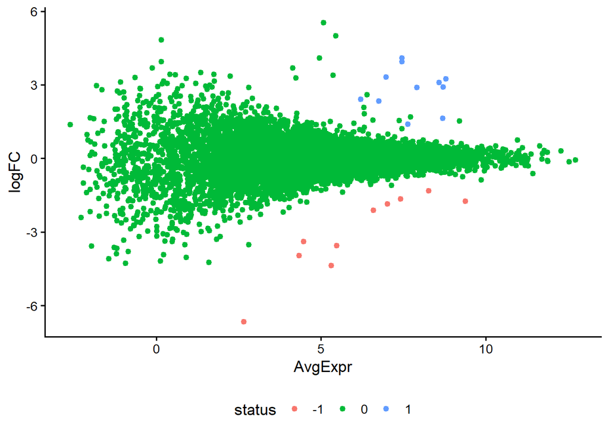

```r
ma_plot_data <- tibble(
  logFC = efit$coefficients[, "casevscontrol"],
  AvgExpr = efit$Amean,
  status = factor(as.numeric(dt[, "casevscontrol"])),
  gene = efit$genes$SYMBOL,
  p_value = efit$p.value[, "casevscontrol"]
)

# Using ggplot and tibble prepared
ma_plot_data |>
  ggplot(aes(x = AvgExpr, y = logFC, col = status)) +
  geom_point()
```

```r
# Refining the MA plot
ma_plot_data_fct <- ma_plot_data |>
  mutate(
    # replace status with a new factor
    status = factor(
      status,
      # levels (order is not DE, down, up)
      levels = c(0, -1, 1),
      labels = c("Not DE", "Lower in PD", "Higher in PD")
    )
  )

## find the top 15 most significant genes to label
top_de_genes <- ma_plot_data_fct |>
  slice_min(n = 15, p_value)

# Using the function topTable() to obtain more information on the differentially expressed gene for contrast between control vs case group
top <- topTable(efit, coef = "casevscontrol", n = Inf)

# To make the dataframe print nicer, let's convert it to a tibble
top_tibble <- as_tibble(top)
top_tibble
```

| genes | SYMBOL | description | logFC | AveExpr | t | P.Value | adj.P.Val | B |
| --- | --- | --- | --- | --- | --- | --- | --- | --- |
| 6014 | RIT2 | Ras like without CAAX 2 | -4.377185e+00 | 5.3049451676 | -6.752173e+00 | 2.034311e-09 | 2.013154e-05 | 9.97826904 |
| 7405 | UVRAG | UV radiation resistance associated | 2.896011e+00 | 7.9163577462 | 6.397132e+00 | 9.621508e-09 | 4.331989e-05 | 9.77851306 |
| 8925 | HERC1 | HECT and RLD domain containing E3 ubiquitin protein ligase family member 1 | 3.090730e+00 | 8.5806524644 | 6.274624e+00 | 1.635838e-08 | 4.331989e-05 | 9.29713210 |
| 5594 | MAPK1 | mitogen-activated protein kinase 1 | -1.751070e+00 | 9.3869202863 | -6.144340e+00 | 2.866714e-08 | 5.673801e-05 | 8.76494848 |
| 9546 | APBA3 | amyloid beta precursor protein binding family A member 3 | -3.557994e+00 | 5.4804716331 | -6.258868e+00 | 1.751006e-08 | 4.331989e-05 | 8.58282408 |
| 1785 | DNM2 | dynamin 2 | 2.907779e+00 | 8.7109435564 | 5.737503e+00 | 1.611339e-07 | 2.657635e-04 | 7.13199046 |
| 5071 | PRKN | parkin RBR E3 ubiquitin protein ligase | 3.242619e+00 | 8.7894303145 | 5.625697e+00 | 2.570389e-07 | 3.633795e-04 | 6.69033683 |
| 345611 | IRGM | immunity related GTPase M | 4.084085e+00 | 7.4627020095 | 5.492555e+00 | 4.461689e-07 | 5.519109e-04 | 6.15146823 |
| 83933 | HDAC10 | histone deacetylase 10 | 3.313436e+00 | 6.9813984804 | 5.169585e+00 | 1.661881e-06 | 1.741777e-03 | 4.92990644 |
| 115992 | RNF166 | ring finger protein 166 | 1.629557e+00 | 8.7003741317 | 5.119911e+00 | 2.028195e-06 | 1.824638e-03 | 4.73261183 |

[output cut: 9886 more lines]

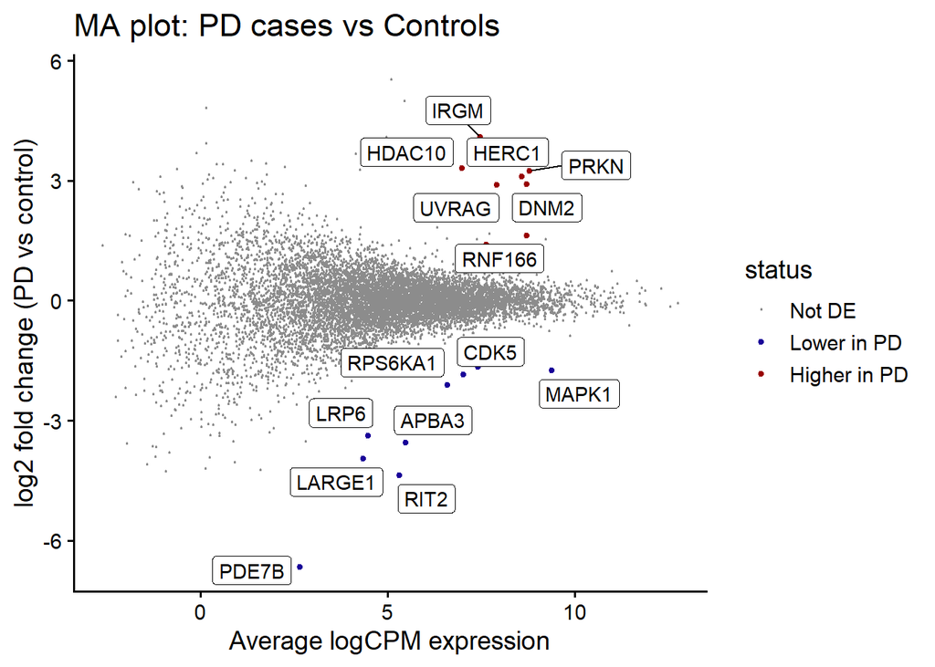

```r
ggplot(ma_plot_data_fct, aes(x = AvgExpr, y = logFC, col = status)) +
  geom_point(
    data = ma_plot_data_fct |>  filter(status == "Not DE"), size = 0.1) +
  geom_point(data = ma_plot_data_fct |>  filter(status != "Not DE"), size = 1) +
  geom_label_repel(
    data = top_de_genes,
    aes(label = gene, col = NULL),
    max.overlaps = 20,
    show.legend = FALSE
  ) +
  scale_colour_manual(values = scale_cols) +
  theme_classic(base_size = 14) +
  labs(title = "MA plot: PD cases vs Controls",
       x = "Average logCPM expression", y = "log2 fold change (PD vs control)")
```

Colours distinguish genes with higher expression in PD, lower expression in PD, and no significant difference. The 15 genes with the smallest raw p-values are labelled.

### 5.2.15 Volcano Plot

The volcano plot shows the size of each gene’s expression change (log2fold change, x-axis) against how statistically significant it is (-log10pvalue). The plot will highlight genes with large statistically differences between PD cases and controls.

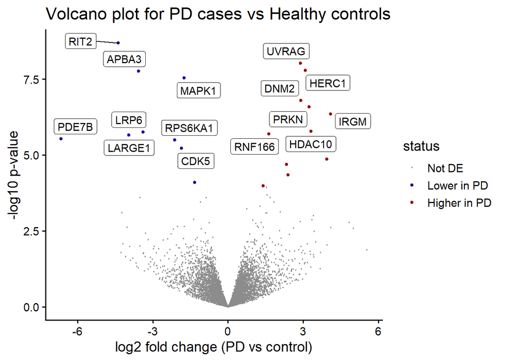

```r
ggplot(ma_plot_data_fct, aes(x = logFC, y = -log10(p_value), col = status)) + #change to adj p
  geom_point(
    data = ma_plot_data_fct |> filter(status == "Not DE"),
    size = 0.1
  ) +
  geom_point(data = ma_plot_data_fct |> filter(status != "Not DE"), size = 1) +
  geom_label_repel(
    data = top_de_genes,
    aes(label = gene, col = NULL),
    max.overlaps = 20,
    show.legend = FALSE
  ) +
  scale_colour_manual(values = scale_cols) +
  theme_classic(base_size = 14) +
  labs(title = "Volcano plot for PD cases vs Healthy controls",
       x = "log2 fold change (PD vs control)", y = "-log10 p-value")
```

### 5.2.16 Linking genes to their gene ontology (GO) terms

We select genes with BH-adjusted p-values below 0.05 and record whether their expression is higher or lower in PD. We then join these genes to the supplied GO annotation table using Entrez IDs and count the annotated genes within each GO category by expression direction.

```r
# Select DE genes (adjusted p<0.05) and record whether each is higher or lower
de_genes <- top_tibble |>
  filter(adj.P.Val < 0.05) |> # What are we using this for
  mutate(direction = if_else(logFC > 0, "Higher in PD", "Lower in PD"))

## Join to the GO table by Entrez ID
de_go <- inner_join(de_genes, gene_ontology,
                    by = join_by(genes == entrezgene_id)) # inner_join keeps only DE genes that appear in the GO table and adds their GO term

# Listing each GO term with its DE genes and their effect sizes
de_go |> arrange(desc, SYMBOL) |> dplyr::select(desc, SYMBOL, logFC, adj.P.Val)
```

| desc | SYMBOL | logFC | adj.P.Val |
| --- | --- | --- | --- |
| Autophagy | ATG5 | 2.341418 | 1.133108e-02 |
| Autophagy | DNM2 | 2.907779 | 2.657635e-04 |
| Autophagy | HDAC10 | 3.313436 | 1.741777e-03 |
| Autophagy | HDAC6 | 3.938456 | 8.582495e-03 |
| Autophagy | HERC1 | 3.090730 | 4.331989e-05 |
| Autophagy | IRGM | 4.084085 | 5.519109e-04 |
| Autophagy | PIK3C3 | 1.397336 | 4.919866e-02 |
| Autophagy | PRKN | 3.242619 | 3.633795e-04 |
| Autophagy | RNF166 | 1.629557 | 1.824638e-03 |
| Autophagy | UVRAG | 2.896011 | 4.331989e-05 |

[output cut: 11 more lines]

```r
# Counts DE genes per GO term and direction
de_go |> count(desc,direction)
```

| desc | direction | n |
| --- | --- | --- |
| Autophagy | Higher in PD | 11 |
| Synaptic transmission | Lower in PD | 10 |

All 21 differentially expressed genes were annotated to their respective GO term in the provided table above, and together they covered 2 GO families: Autophagy and Synaptic transmission. Autophagy contained 11 genes that were higher in PD, while Synaptic transmission contained 10 lower. This shows the biological processes the DE genes are associated with.

### 5.2.17 Creating a Heatmap

We create a heatmap of the top 30 genes returned by topTable() to compare their expression patterns across samples. The heatmap uses logCPM values scaled within each gene, so colours represent relative expression across samples rather than absolute differences between genes. Hierarchical clustering groups genes and samples with similar expression patterns. The selected genes are top-ranked genes, not necessarily all statistically significant.

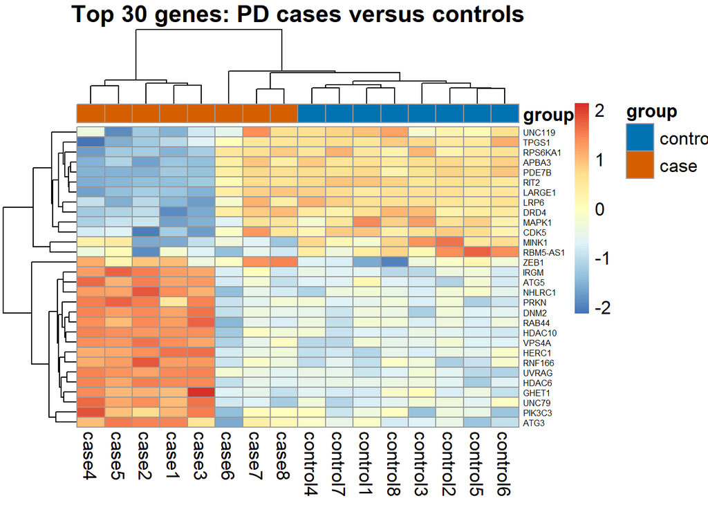

```r
# The 30 most significant genes for our contrast (What does signif mean, toptable is automatically sorted, by adj p-value)
top_genes <- bind_rows(
  topTable(efit, coef = "casevscontrol", n = 30)
) |>
  dplyr::select(genes, SYMBOL)  |>
  distinct() # remove duplicates

# Filter the count matrix to find just those genes and label rows with genes names
top_gene_expr <- cpm(dge, log = TRUE)[as.character(top_genes$genes), ]
rownames(top_gene_expr) <- top_genes$SYMBOL

# Annotation information for the heatmap
sample_anno <- data.frame(
  group = dge$samples$group,
  row.names = rownames(dge$samples))

heatmap <- pheatmap(
    top_gene_expr,
    scale = "row",
    annotation_col = sample_anno,
    border_colour = NA,
    cluster_rows = TRUE,
    cluster_cols = TRUE,
    show_rownames = TRUE,
    show_colnames = TRUE,
    fontsize_row = 6,
    annotation_colors = list(group = group_colours),
    main = "Top 30 genes: PD cases versus controls", fontsize = 13)
```

## 5.3 Questions

### 5.3.1 Question 1

*Which genes are differentially expressed between PD cases and healthy controls? Please also visualise your DE results with appropriate plot(s)*

Differential expression analysis identified 21 genes with statistiscally signfifcant differences in expression between PD cases and healthy controls (adjusted p<0.05). Of these 11 genes (UVRAG, HERC1, DNM2,PRKN, IRGM, HDAC10, RNF166, HDAC6, ATG5 , VPS4A and PIK3C3) were found to be upregulated and showed higher expression in PD cases , while the remaining 10 genes were downregultated (RIT2, MAPK1, APBA3, RPS6KA1, LRP6, CDK5, LARGE1, DRD4, UNC119 and PDE7B), showing a lower expression in PD cases in comparison to the controls.

The MA plot shows the log2fold change of each gene against its average expression. Most genes cluster around zero, indicating that their expression did not change substantially between groups, suggesting normalisation was also performed. The differentially expressed genes lie above zero, if therre is a greater log2fold change corresponding to higher expression in PD cases, or below zero, if there is a reduced expression in PD cases. These is no obvious trend in fold change across expression levels, though this visual assessment alone cannot rule out all systematic bias.

These findings have identified a set of genes which differs in expression between PD and healthy control cases. However, statistical significance does not necessarily indicate biological importance, and the magnitude of fold changes needs to be carefully evaluated alongside expression levels and the sample size of the study.Whilst the analysis identifies associations with disease status, it does not establish whether these expression changes contribute to PD or may be consequences of the disease that result in gene expression changes.

### 5.3.2 Question 2

*Which gene ontology families do the DE genes belong to?*

The gene ontology analysis grouped the differntially expressed genes into two reported functional categories: autphagy and synaptic transmission. The upregulated genes were all annotated to autophagy, including RKN, ATG5, and VPS4A, whereas the downregulated genes were associated with synaptic transmission including RIT2, CDK5, and APBA3. These categories were identified by joining the differentially expressed genes to the gene ontology annotatiion table by Entrez IDs and counting annotated genes by expression direction.

The upregulated expression of autophagy genes may reflect changes in cellular processes involved in portein and organelle turnover, as neurons respond to protein accumulation or mitochondrial stress, while the downregulation of synaptic transmission gene may be consistent with reduced neuronal signalling in PD neurons. Though, these are only intial interpretations as increase or decrease expression of genes may not directly translate to downstream responses. Furthermore, the findings depend on the annotations and selection of genes in the dataset. These results should therefore only be interpreted as functional annotations of the identified genes.

### 5.3.3 Question 3

*Is the clustering of samples by gene expression consistent with their disease status as cases and controls?*

The MDS plot shows partial separation between PD cases and healthy controls based on their gene expression profiles. Cases 1 to 5 cluster on the right at positive values of dimension , whereas controls 1 to 8 cluster on the left at negative values. However, cases 6, 7 and 8 cluster closer to the controls, suggesting heterogeneity between patients as this reflect variation in gene expression profile among the PD cases. Overall, the clustering is partly consistent with disease status, although the groups are not completely separated. Dimension 1 accounts for 9 % while dimension 2 explains a further 7%. Together, these two dimension represent approximately 16% of the variation, meaning that the MDS plot captures only part of the overall differences between samples. Therefore, samples that appear similar in the MDS plot may still differ in their gene expression profiles, as the plot only displays a relative small proportion of the overall variation. This provides a limited representation of the relationship between samples.

The heatmap of the top 30 genes in the datasets, which includes the differentially expressed genes, shows a similar pattern. Hierarchical clustering groups cases 1 to 5 separately from the controls, while cases 6,7 and 8 form a small cluster branch closer to the controls. This supports the MDS observation that the expression profiles of cases 1 to 5 differ more clearly from those of the controls, whilst cases 6 to 8 show greater similarity to the control cases for the selected genes displayed.

Taken together, the MDS plot and heatmap suggest that gene expression patterns are partially associated with disease status, but do not completely distinguish PD cases from healthy controls. The small sample size (eight cases and eight controls) limits the interpretation of these observed patterns. Furthermore, these visualisation alone cannot establish the cause of the observed clustering of expression pattern or determine how reliably gene expression profile distinguish between the groups.

# 6 Drug screening

## 6.1 Background

This section analyses a high-throughput drug screen performed in healthy donor iPSC-derived dopaminergic neurons exposed to MPP. MPP causes oxidative stress and mitochondrial dysfunction, providing an in vitro model of Parkinson’s disease-related neuronal injury.

Neuronal viability was measured by luminescence in relative light units (RLU). Higher RLU indicates greater apparent neuronal survival after MPP exposure.

### 6.1.1 Aims

1. Does luminescence show any spatial pattern(s) across the 1,536-well plate.
2. Which test compounds are associated with increased neuronal viability relative to their chemically matched inactive controls?
3. What are the mechanisms of action and targets of statistically significant compounds.

## 6.2 Inspect input data

```r
## plate1 contains luminescence values for each plate well.
## plate_meta contains the compound label for each corresponding well.
## compound_dict contains target and mechanism annotation for each test compound.

head(plate1)
```

| plate_row | col1 | col2 | col3 | col4 | col5 | col6 | col7 | col8 | col9 | col10 | col11 | col12 | col13 | col14 | col15 | col16 | col17 | col18 | col19 | col20 | col21 | col22 | col23 | col24 | col25 | col26 | col27 | col28 | col29 | … |
| --- | --- | --- | --- | --- | --- | --- | --- | --- | --- | --- | --- | --- | --- | --- | --- | --- | --- | --- | --- | --- | --- | --- | --- | --- | --- | --- | --- | --- | --- | --- |
| row1 | 694 | 494 | 550 | 500 | 530 | 537 | 476 | 515 | 468 | 499 | 485 | 502 | 517 | 549 | 483 | 505 | 513 | 465 | 459 | 513 | 490 | 494 | 461 | 508 | 521 | 471 | 524 | 511 | 486 | … |
| row2 | 516 | 495 | 553 | 510 | 479 | 456 | 505 | 495 | 483 | 516 | 525 | 523 | 527 | 475 | 515 | 453 | 499 | 470 | 499 | 516 | 525 | 529 | 469 | 466 | 482 | 535 | 501 | 514 | 524 | … |
| row3 | 458 | 511 | 485 | 496 | 492 | 521 | 521 | 524 | 523 | 517 | 533 | 482 | 515 | 489 | 514 | 468 | 522 | 484 | 546 | 502 | 504 | 505 | 517 | 508 | 521 | 470 | 524 | 459 | 727 | … |
| row4 | 457 | 468 | 490 | 518 | 512 | 498 | 466 | 499 | 496 | 474 | 493 | 522 | 503 | 518 | 519 | 491 | 543 | 499 | 524 | 467 | 454 | 513 | 512 | 519 | 500 | 479 | 481 | 464 | 477 | … |
| row5 | 472 | 477 | 480 | 518 | 507 | 490 | 511 | 462 | 472 | 524 | 505 | 476 | 532 | 479 | 465 | 478 | 527 | 453 | 505 | 523 | 548 | 518 | 523 | 528 | 475 | 465 | 486 | 505 | 505 | … |
| row6 | 539 | 490 | 508 | 515 | 516 | 489 | 505 | 498 | 497 | 479 | 498 | 532 | 530 | 493 | 521 | 503 | 501 | 480 | 486 | 495 | 482 | 461 | 509 | 484 | 675 | 502 | 511 | 517 | 504 | … |

```r
head(plate_meta)
```

| plate_row | col1 | col2 | col3 | col4 | col5 | col6 | col7 | col8 | col9 | col10 | col11 | col12 | col13 | col14 | col15 | col16 | col17 | col18 | col19 | col20 | col21 | col22 | col23 | col24 | col25 | col26 | col27 | col28 | col29 | … |
| --- | --- | --- | --- | --- | --- | --- | --- | --- | --- | --- | --- | --- | --- | --- | --- | --- | --- | --- | --- | --- | --- | --- | --- | --- | --- | --- | --- | --- | --- | --- |
| row1 | cmpd_5631_test | cmpd_7511_ctrl | cmpd_5177_ctrl | cmpd_6911_test | cmpd_7717_ctrl | cmpd_6748_test | cmpd_5205_ctrl | cmpd_5643_ctrl | cmpd_5567_test | cmpd_4737_test | cmpd_4731_test | cmpd_6859_ctrl | cmpd_7641_test | cmpd_7851_ctrl | cmpd_7354_ctrl | cmpd_4243_test | cmpd_6479_ctrl | cmpd_6100_test | cmpd_5543_ctrl | cmpd_5154_ctrl | cmpd_4875_ctrl | cmpd_6100_ctrl | cmpd_7720_ctrl | cmpd_6873_test | cmpd_7657_ctrl | cmpd_5099_test | cmpd_7394_test | cmpd_6478_test | cmpd_5455_test | … |
| row2 | cmpd_7343_ctrl | cmpd_7198_test | cmpd_5887_ctrl | cmpd_6219_test | cmpd_4722_test | cmpd_4996_ctrl | cmpd_6803_ctrl | cmpd_5194_test | cmpd_6383_test | cmpd_5498_ctrl | cmpd_7328_test | cmpd_5643_test | cmpd_5026_test | cmpd_7811_ctrl | cmpd_6855_test | cmpd_7360_ctrl | cmpd_7369_test | cmpd_5643_test | cmpd_4491_test | cmpd_7216_test | cmpd_7929_test | cmpd_6692_ctrl | cmpd_6933_test | cmpd_7157_ctrl | cmpd_7485_test | cmpd_4243_ctrl | cmpd_7170_test | cmpd_6172_test | cmpd_6998_test | … |
| row3 | cmpd_4421_ctrl | cmpd_5388_test | cmpd_4737_ctrl | cmpd_4114_ctrl | cmpd_5138_ctrl | cmpd_7053_test | cmpd_6367_test | cmpd_6874_ctrl | cmpd_7482_ctrl | cmpd_6776_ctrl | cmpd_6911_ctrl | cmpd_6655_ctrl | cmpd_5332_ctrl | cmpd_4046_test | cmpd_4737_ctrl | cmpd_5978_ctrl | cmpd_7140_ctrl | cmpd_6313_ctrl | cmpd_6529_test | cmpd_6230_test | cmpd_7851_ctrl | cmpd_4283_test | cmpd_5543_ctrl | cmpd_7053_ctrl | cmpd_5292_ctrl | cmpd_7641_ctrl | cmpd_6349_test | cmpd_5052_test | cmpd_5706_test | … |
| row4 | cmpd_4060_ctrl | cmpd_7257_test | cmpd_4810_test | cmpd_6349_ctrl | cmpd_6796_test | cmpd_6748_test | cmpd_4047_test | cmpd_7368_ctrl | cmpd_6998_test | cmpd_7301_test | cmpd_5367_ctrl | cmpd_5706_ctrl | cmpd_7495_test | cmpd_7641_ctrl | cmpd_5070_ctrl | cmpd_6311_ctrl | cmpd_5090_test | cmpd_7369_ctrl | cmpd_5567_ctrl | cmpd_6479_test | cmpd_5407_ctrl | cmpd_6932_ctrl | cmpd_4810_ctrl | cmpd_4060_ctrl | cmpd_5269_test | cmpd_6696_test | cmpd_4047_test | cmpd_7498_test | cmpd_5463_test | … |
| row5 | cmpd_7780_test | cmpd_7685_test | cmpd_6366_ctrl | cmpd_6313_test | cmpd_6591_test | cmpd_5292_ctrl | cmpd_4491_ctrl | cmpd_7945_test | cmpd_5463_ctrl | cmpd_5269_test | cmpd_7170_test | cmpd_6697_test | cmpd_4442_ctrl | cmpd_7532_ctrl | cmpd_7685_test | cmpd_4243_ctrl | cmpd_5649_ctrl | cmpd_5989_test | cmpd_5070_ctrl | cmpd_7053_test | cmpd_7394_ctrl | cmpd_5494_test | cmpd_7811_ctrl | cmpd_6748_ctrl | cmpd_4987_ctrl | cmpd_7257_ctrl | cmpd_4114_test | cmpd_5140_ctrl | cmpd_7564_test | … |
| row6 | cmpd_5138_test | cmpd_4060_ctrl | cmpd_7498_ctrl | cmpd_4223_ctrl | cmpd_7157_test | cmpd_4114_ctrl | cmpd_5694_test | cmpd_5368_ctrl | cmpd_4145_test | cmpd_6176_test | cmpd_6591_test | cmpd_7657_test | cmpd_6910_ctrl | cmpd_5292_test | cmpd_4663_test | cmpd_4296_test | cmpd_4114_ctrl | cmpd_7425_ctrl | cmpd_6311_ctrl | cmpd_7482_ctrl | cmpd_6890_ctrl | cmpd_6890_ctrl | cmpd_7216_ctrl | cmpd_5551_ctrl | cmpd_4996_test | cmpd_6806_ctrl | cmpd_6234_ctrl | cmpd_7394_ctrl | cmpd_7368_test | … |

```r
head(compound_dict)
```

| id | target_enzyme | action | hgnc_symbol |
| --- | --- | --- | --- |
| cmpd_4046 | 9945 | antagonist | GFPT2 |
| cmpd_4047 | 1558 | agonist | CYP2C8 |
| cmpd_4060 | 1576 | antagonist | CYP3A4 |
| cmpd_4114 | 3702 | agonist | ITK |
| cmpd_4145 | 57097 | agonist | PARP11 |
| cmpd_4222 | 8844 | antagonist | KSR1 |

```r
## Confirm the measurement and metadata plates have identical dimensions
## and matching column and row names before joining them.
stopifnot(identical(names(plate1), names(plate_meta)))
stopifnot(identical(plate1$plate_row, plate_meta$plate_row))

## Display data structure.
glimpse(plate1)
```

```
Rows: 32
Columns: 49
$ plate_row <chr> "row1", "row2", "row3", "row4", "row5", "row6", "row7", "row…
$ col1      <dbl> 694, 516, 458, 457, 472, 539, 475, 545, 474, 496, 525, 482, …
$ col2      <dbl> 494, 495, 511, 468, 477, 490, 457, 463, 477, 498, 506, 483, …
$ col3      <dbl> 550, 553, 485, 490, 480, 508, 484, 528, 474, 501, 514, 538, …
$ col4      <dbl> 500, 510, 496, 518, 518, 515, 534, 468, 478, 471, 529, 476, …
$ col5      <dbl> 530, 479, 492, 512, 507, 516, 489, 542, 509, 497, 487, 512, …
$ col6      <dbl> 537, 456, 521, 498, 490, 489, 486, 494, 520, 540, 535, 529, …
$ col7      <dbl> 476, 505, 521, 466, 511, 505, 530, 490, 518, 499, 515, 478, …
$ col8      <dbl> 515, 495, 524, 499, 462, 498, 489, 516, 498, 558, 500, 462, …
$ col9      <dbl> 468, 483, 523, 496, 472, 497, 473, 494, 463, 534, 511, 505, …
$ col10     <dbl> 499, 516, 517, 474, 524, 479, 485, 534, 481, 497, 502, 506, …
$ col11     <dbl> 485, 525, 533, 493, 505, 498, 514, 523, 465, 515, 497, 469, …
$ col12     <dbl> 502, 523, 482, 522, 476, 532, 500, 459, 545, 498, 522, 489, …
```

[output cut: 36 more lines]

```r
glimpse(plate_meta)
```

```
Rows: 32
Columns: 49
$ plate_row <chr> "row1", "row2", "row3", "row4", "row5", "row6", "row7", "row…
$ col1      <chr> "cmpd_5631_test", "cmpd_7343_ctrl", "cmpd_4421_ctrl", "cmpd_…
$ col2      <chr> "cmpd_7511_ctrl", "cmpd_7198_test", "cmpd_5388_test", "cmpd_…
$ col3      <chr> "cmpd_5177_ctrl", "cmpd_5887_ctrl", "cmpd_4737_ctrl", "cmpd_…
$ col4      <chr> "cmpd_6911_test", "cmpd_6219_test", "cmpd_4114_ctrl", "cmpd_…
$ col5      <chr> "cmpd_7717_ctrl", "cmpd_4722_test", "cmpd_5138_ctrl", "cmpd_…
$ col6      <chr> "cmpd_6748_test", "cmpd_4996_ctrl", "cmpd_7053_test", "cmpd_…
$ col7      <chr> "cmpd_5205_ctrl", "cmpd_6803_ctrl", "cmpd_6367_test", "cmpd_…
$ col8      <chr> "cmpd_5643_ctrl", "cmpd_5194_test", "cmpd_6874_ctrl", "cmpd_…
$ col9      <chr> "cmpd_5567_test", "cmpd_6383_test", "cmpd_7482_ctrl", "cmpd_…
$ col10     <chr> "cmpd_4737_test", "cmpd_5498_ctrl", "cmpd_6776_ctrl", "cmpd_…
$ col11     <chr> "cmpd_4731_test", "cmpd_7328_test", "cmpd_6911_ctrl", "cmpd_…
$ col12     <chr> "cmpd_6859_ctrl", "cmpd_5643_test", "cmpd_6655_ctrl", "cmpd_…
```

[output cut: 36 more lines]

```r
glimpse(compound_dict)
```

```
Rows: 192
Columns: 4
$ id            <chr> "cmpd_4046", "cmpd_4047", "cmpd_4060", "cmpd_4114", "cmp…
$ target_enzyme <int> 9945, 1558, 1576, 3702, 57097, 8844, 2548, 212, 7374, 64…
$ action        <chr> "antagonist", "agonist", "antagonist", "agonist", "agoni…
$ hgnc_symbol   <chr> "GFPT2", "CYP2C8", "CYP3A4", "ITK", "PARP11", "KSR1", "G…
```

There should be three dataframes loaded:

1. ‘plate1’ contains luminescence values in relative light units (RLU).
2. ‘plate_meta’ has the compound that is added in each well.
3. ‘compound_dict’ contains the enzyme target and mechanism of action for each of the test compounds.

## 6.3 Data preparation

### 6.3.1 Convert plate data to tidy format

The raw plate tables are in wide format: one row per plate row and one column per plate column. For visualisation and statistical testing, the data are converted to tidy format, where every row represents one physical well.

```r
## Convert luminescence data from wide format to one row per well.
plate_values_long <- plate1%>%
  pivot_longer(
    cols = starts_with("col"), #
    names_to = "plate_col", #
    values_to = "rlu" #
  )

## Convert compound identities from wide format to one row per well.
plate_meta_long <- plate_meta %>%
  pivot_longer(
    cols = starts_with("col"),
    names_to = "plate_col",
    values_to = "compound_label"
  )

## Join luminescence values to their matching compound labels.
## Also create numeric row/column positions and identify whether each well
## contains an active test compound or its matched inactive control.
plate_long <- plate_values_long %>%
  left_join(plate_meta_long, by = c("plate_row", "plate_col")) %>%
  mutate(
    row_number = parse_number(plate_row),
    col_number = parse_number(plate_col),
    # Remove _test or _ctrl to give both members of a pair the same ID.
    compound_id = str_remove(compound_label, "_(test|ctrl)$"),
    # Identify active compounds and chemically matched inactive controls.
    treatment_type = case_when(
      str_detect(compound_label, "_test$") ~ "Test compound",
      str_detect(compound_label, "_ctrl$") ~ "Matched control"
    ),
    # Create a conventional plate-well label, e.g. A1, B12 or AF48.
    well = paste0(LETTERS[row_number], col_number)
  )

## Quality-control checks: confirm every physical well was retained and labelled.
stopifnot(nrow(plate_long) == 32 * 48)
stopifnot(!any(is.na(plate_long$rlu)))
stopifnot(!any(is.na(plate_long$compound_label)))
stopifnot(!any(is.na(plate_long$treatment_type)))

plate_long %>%
  slice_head(n = 10) %>%
  kable(caption = "First 10 wells in tidy format")
```

First 10 wells in tidy format

| plate_row | plate_col | rlu | compound_label | row_number | col_number | compound_id | treatment_type | well |
| --- | --- | --- | --- | --- | --- | --- | --- | --- |
| row1 | col1 | 694 | cmpd_5631_test | 1 | 1 | cmpd_5631 | Test compound | A1 |
| row1 | col2 | 494 | cmpd_7511_ctrl | 1 | 2 | cmpd_7511 | Matched control | A2 |
| row1 | col3 | 550 | cmpd_5177_ctrl | 1 | 3 | cmpd_5177 | Matched control | A3 |
| row1 | col4 | 500 | cmpd_6911_test | 1 | 4 | cmpd_6911 | Test compound | A4 |
| row1 | col5 | 530 | cmpd_7717_ctrl | 1 | 5 | cmpd_7717 | Matched control | A5 |
| row1 | col6 | 537 | cmpd_6748_test | 1 | 6 | cmpd_6748 | Test compound | A6 |
| row1 | col7 | 476 | cmpd_5205_ctrl | 1 | 7 | cmpd_5205 | Matched control | A7 |
| row1 | col8 | 515 | cmpd_5643_ctrl | 1 | 8 | cmpd_5643 | Matched control | A8 |
| row1 | col9 | 468 | cmpd_5567_test | 1 | 9 | cmpd_5567 | Test compound | A9 |
| row1 | col10 | 499 | cmpd_4737_test | 1 | 10 | cmpd_4737 | Test compound | A10 |

### 6.3.2 Confirm replicate structure

Every test compound and every matched control should occur in four technical replicate wells.

```r
## Count wells for every compound-treatment combination.
replicate_check <- plate_long %>%
  count(compound_id, treatment_type, name = "n_wells")

## Summarise the number of compounds with each replicate count.
replicate_check %>%
  count(treatment_type, n_wells, name = "n_compounds") %>%
  kable(caption = "Technical replicate structure")
```

Technical replicate structure

| treatment_type | n_wells | n_compounds |
| --- | --- | --- |
| Matched control | 4 | 192 |
| Test compound | 4 | 192 |

```r
## This should be empty. Any output identifies compounds with a replicate
## number other than four and should be investigated before interpretation.
replicate_check %>%
  filter(n_wells != 4)
```

| compound_id | treatment_type | n_wells |
| --- | --- | --- |

### 6.3.3 Confirm compound annotation

```r
## All active test compounds should be present in compound_dict.
## This table should be empty; otherwise, those compounds cannot be annotated.
plate_long %>%
  filter(treatment_type == "Test compound") %>%
  distinct(compound_id) %>%
  anti_join(compound_dict, by = c("compound_id" = "id"))
```

| compound_id |
| --- |

## 6.4 Plate visualisation

### 6.4.1 Distribution of luminescence

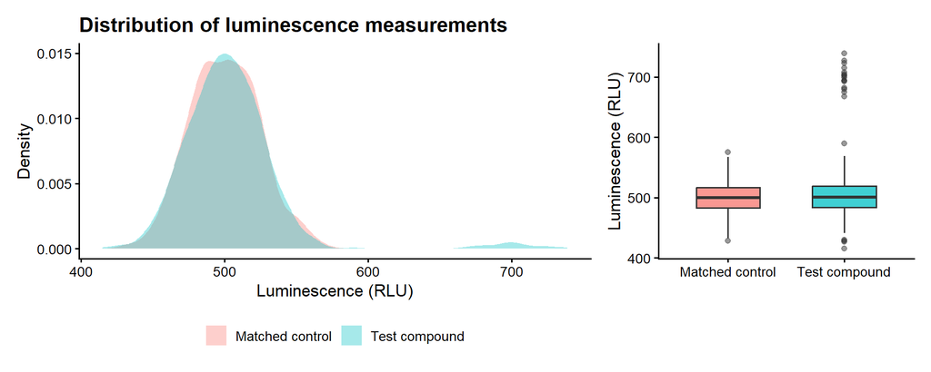

```r
## Plot the distribution of all RLU values by treatment type.
p_density <- ggplot(plate_long, aes(x = rlu, fill = treatment_type)) +
  geom_density(alpha = 0.35, colour = NA) +
  labs(
    title = "Distribution of luminescence measurements",
    x = "Luminescence (RLU)",
    y = "Density",
    fill = NULL
  )

## A boxplot provides a compact view of each treatment distribution.
p_boxplot <- ggplot(plate_long, aes(x = treatment_type, y = rlu, fill = treatment_type)) +
  geom_boxplot(width = 0.55, alpha = 0.75, outlier.alpha = 0.5) +
  labs(
    x = NULL,
    y = "Luminescence (RLU)",
    fill = NULL
  ) +
  theme(legend.position = "none")

## Combine the two complementary plots.
p_density + p_boxplot + plot_layout(widths = c(2, 1))
```

### 6.4.2 Plate heatmap

`geom_tile()` places a coloured rectangle at each row-column coordinate. The fill colour represents luminescence intensity.

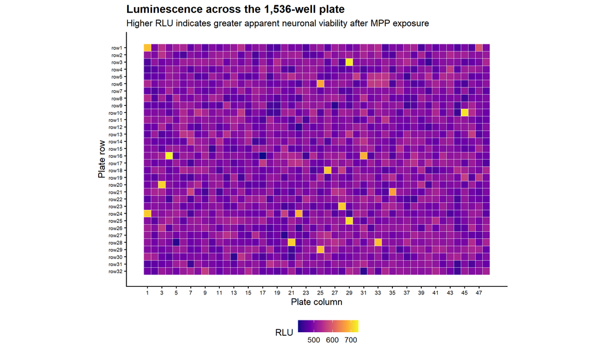

```r
ggplot(plate_long, aes(x = col_number, y = row_number, fill = rlu)) +
  geom_tile(colour = "white", linewidth = 0.15) +
  scale_y_reverse(
    breaks = 1:32,
    labels = paste0("row", 1:32)
  ) +
  scale_x_continuous(breaks = seq(1, 48, by = 2)) +
  scale_fill_viridis_c(
    option = "C",
    name = "RLU"
  ) +
  coord_fixed() +
  labs(
    title = "Luminescence across the 1,536-well plate",
    subtitle = "Higher RLU indicates greater apparent neuronal viability after MPP exposure",
    x = "Plate column",
    y = "Plate row"
  ) +
  theme(
    panel.grid = element_blank(),
    axis.text.y = element_text(size = 7),
    axis.text.x = element_text(size = 8)
  )
```

### 6.4.3 Row and column diagnostics

The heatmap is the main spatial diagnostic. These two plots provide supporting descriptive evidence for possible row or column trends.

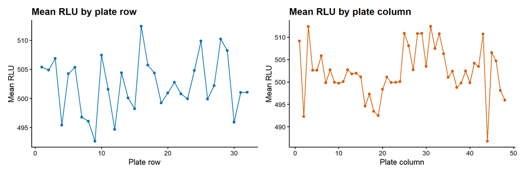

```r
## Calculate mean RLU for each physical row.
row_summary <- plate_long %>%
  group_by(row_number) %>%
  summarise(mean_rlu = mean(rlu), .groups = "drop")

## Calculate mean RLU for each physical column.
col_summary <- plate_long %>%
  group_by(col_number) %>%
  summarise(mean_rlu = mean(rlu), .groups = "drop")

## Plot average RLU across plate rows.
p_row <- ggplot(row_summary, aes(x = row_number, y = mean_rlu)) +
  geom_line(colour = "#0072B2", linewidth = 0.7) +
  geom_point(colour = "#0072B2") +
  labs(
    title = "Mean RLU by plate row",
    x = "Plate row",
    y = "Mean RLU"
  )

## Plot average RLU across plate columns.
p_col <- ggplot(col_summary, aes(x = col_number, y = mean_rlu)) +
  geom_line(colour = "#D55E00", linewidth = 0.7) +
  geom_point(colour = "#D55E00") +
  labs(
    title = "Mean RLU by plate column",
    x = "Plate column",
    y = "Mean RLU"
  )

p_row + p_col
```

## 6.5 Questions

### 6.5.1 Question 1

*Using the geom_tile() function, visualise the luminescence across the plate. Do there appear to be any spatial patterns in this data?*

```r
#fit the RLU across both rows and columns as linear models
row_model <- lm(rlu ~ row_number, data = plate_long)
col_model <- lm(rlu ~ col_number, data = plate_long)

row_slope <- coef(row_model)[["row_number"]]
col_slope <- coef(col_model)[["col_number"]]
row_p <- tidy(row_model) %>% filter(term == "row_number") %>% pull(p.value)
col_p <- tidy(col_model) %>% filter(term == "col_number") %>% pull(p.value)

row_range <- range(row_summary$mean_rlu)
col_range <- range(col_summary$mean_rlu)

spatial_answer <- case_when(
  row_p >= 0.05 & col_p >= 0.05 ~
    "There was no evidence of a systematic linear row or column gradient.",
  row_p < 0.05 & col_p >= 0.05 ~
    "There was evidence of a row-associated gradient but not a column gradient.",
  row_p >= 0.05 & col_p < 0.05 ~
    "There was evidence of a column-associated gradient but not a row gradient.",
  TRUE ~
    "There was evidence of both row- and column-associated gradients."
)

cat(
  "**Answer.** ", spatial_answer,
  " Mean RLU ranged from ", round(row_range[1], 1), " to ",
  round(row_range[2], 1), " across rows and from ",
  round(col_range[1], 1), " to ", round(col_range[2], 1),
  " across columns. The estimated slopes were ", round(row_slope, 3),
  " RLU per row (p = ", signif(row_p, 3), ") and ",
  round(col_slope, 3), " RLU per column (p = ", signif(col_p, 3),
  "). The heatmap should also be inspected for isolated or non-linear patterns ",
  "that these simple trend models cannot capture."
)
```

**Answer.** There was no evidence of a systematic linear row or column gradient. Mean RLU ranged from 492.6 to 512.4 across rows and from 486.8 to 512.4 across columns. The estimated slopes were 0.05 RLU per row (p = 0.572 ) and 0.016 RLU per column (p = 0.787 ). The heatmap should also be inspected for isolated or non-linear patterns that these simple trend models cannot capture.

There was no evidence of a systematic linear row or column gradient. Mean RLU ranged from 492.6 to 512.4 across rows and from 486.8 to 512.4 across columns. The estimated slopes were 0.05 RLU per row (p = 0.572 ) and 0.016 RLU per column (p = 0.787 ). Additional visual inspection of the heatmap also does not seem to infer any spatial trends.

### 6.5.2 Question 2

*Which compounds are statistically significantly associated with increased neuronal viability after MPP exposure? Ensure that you check your assumptions.*

#### 6.5.2.1 Effect estimates

Each active test compound is compared only with its own chemically matched inactive control. The primary effect is the mean RLU difference (test minus control); positive values favour the active compound. Fold change is included as a scale-free descriptive effect.

```r
compound_summary <- plate_long %>%
  mutate(
    treatment_short = recode(
      as.character(treatment_type),
      "Matched control" = "control",
      "Test compound" = "test"
    )
  ) %>%
  group_by(compound_id, treatment_short) %>%
  summarise(
    n_wells = n(),
    mean_rlu = mean(rlu),
    sd_rlu = sd(rlu),
    .groups = "drop"
  ) %>%
  pivot_wider(
    names_from = treatment_short,
    values_from = c(n_wells, mean_rlu, sd_rlu),
    names_glue = "{.value}_{treatment_short}"
  ) %>%
  mutate(
    effect_rlu = mean_rlu_test - mean_rlu_control,
    fold_change = mean_rlu_test / mean_rlu_control
  ) %>%
  arrange(desc(effect_rlu))

# Show the largest descriptive increases before considering uncertainty.
compound_summary %>%
  dplyr::select(
    compound_id,
    mean_rlu_test,
    mean_rlu_control,
    effect_rlu,
    fold_change
  ) %>%
  slice_head(n = 10) %>%
  mutate(across(where(is.numeric), ~ round(.x, 3)))
```

| compound_id | mean_rlu_test | mean_rlu_control | effect_rlu | fold_change |
| --- | --- | --- | --- | --- |
| cmpd_5706 | 714.25 | 512.50 | 201.75 | 1.394 |
| cmpd_5631 | 704.75 | 507.25 | 197.50 | 1.389 |
| cmpd_4996 | 690.25 | 504.25 | 186.00 | 1.369 |
| cmpd_5986 | 692.25 | 515.00 | 177.25 | 1.344 |
| cmpd_6529 | 543.50 | 483.75 | 59.75 | 1.124 |
| cmpd_7328 | 532.75 | 485.50 | 47.25 | 1.097 |
| cmpd_7717 | 523.75 | 483.75 | 40.00 | 1.083 |
| cmpd_5165 | 520.50 | 481.75 | 38.75 | 1.080 |
| cmpd_5070 | 535.00 | 501.25 | 33.75 | 1.067 |
| cmpd_7347 | 505.50 | 471.75 | 33.75 | 1.072 |

#### 6.5.2.2 Statistical approach

A one-sided Welch two-sample *t* test is applied separately to each compound because the research question asks specifically whether mean RLU is higher for the active compound. Welch’s test does not require equal group variances. The Benjamini-Hochberg procedure controls the false discovery rate (FDR) across the 192 primary tests. A hit is defined *a priori* as a positive mean difference with BH-adjusted p < 0.05.

A one-sided Wilcoxon rank-sum test is also calculated as a sensitivity analysis. It does not create additional hits; it indicates whether the direction of a Welch-FDR hit is also supported without assuming normality. Its p-values are BH-adjusted across the same 192 compounds.

```r
# split() creates one eight-well data frame for each compound-control pair.
compound_list <- split(plate_long, plate_long$compound_id)

# Run identical tests for every compound, retaining both effects and p-values.
test_results <- map_dfr(compound_list, function(compound_data) {
  test_values <- compound_data %>%
    filter(treatment_type == "Test compound") %>%
    pull(rlu)

  control_values <- compound_data %>%
    filter(treatment_type == "Matched control") %>%
    pull(rlu)

  welch_result <- t.test(
    test_values,
    control_values,
    alternative = "greater",
    var.equal = FALSE
  )

  wilcox_result <- wilcox.test(
    test_values,
    control_values,
    alternative = "greater",
    exact = FALSE
  )

  tibble(
    compound_id = unique(compound_data$compound_id),
    mean_test_rlu = mean(test_values),
    mean_control_rlu = mean(control_values),
    effect_rlu = mean(test_values) - mean(control_values),
    fold_change = mean(test_values) / mean(control_values),
    t_statistic = unname(welch_result$statistic),
    degrees_freedom = unname(welch_result$parameter),
    p_value = welch_result$p.value,
    wilcox_p_value = wilcox_result$p.value
  )
})

compound_tests <- test_results %>%
  mutate(
    fdr_bh = p.adjust(p_value, method = "BH"),
    wilcox_fdr_bh = p.adjust(wilcox_p_value, method = "BH"),
    hit = effect_rlu > 0 & fdr_bh < 0.05,
    wilcox_support = wilcox_fdr_bh < 0.05
  ) %>%
  left_join(compound_dict, by = c("compound_id" = "id")) %>%
  arrange(fdr_bh, desc(effect_rlu))

# Annotation must remain complete after the join.
stopifnot(!anyNA(compound_tests$hgnc_symbol))

n_hits <- sum(compound_tests$hit)
n_wilcox_supported <- sum(
  compound_tests$hit & compound_tests$wilcox_support
)
```

#### 6.5.2.3 Assumption checks

The outcome is continuous and each comparison contains two groups. Equal variance is not required because Welch’s correction is used. Normality is assessed within each condition using Q-Q plots and Shapiro-Wilk tests, as taught in the course. With only four observations per group, both diagnostics have limited ability to identify non-normality; the Wilcoxon analysis therefore checks whether the leading conclusions depend strongly on the normality assumption.

The following plots show FDR hits, followed by the strongest positive non-significant candidates if fewer than eight hits are present. Selection is for readable diagnostics only and does not alter the tests or FDR correction.

```r
# Prioritise declared hits, then fill remaining spaces by adjusted p-value.
diagnostic_candidates <- compound_tests %>%
  filter(effect_rlu > 0) %>%
  arrange(desc(hit), fdr_bh, desc(effect_rlu)) %>%
  slice_head(n = 8) %>%
  pull(compound_id)

normality_check <- plate_long %>%
  group_by(compound_id, treatment_type) %>%
  summarise(
    # Shapiro-Wilk is undefined if all four observations are identical.
    shapiro_p = if (sd(rlu) == 0) {
      NA_real_
    } else {
      shapiro.test(rlu)$p.value
    },
    .groups = "drop"
  )
```

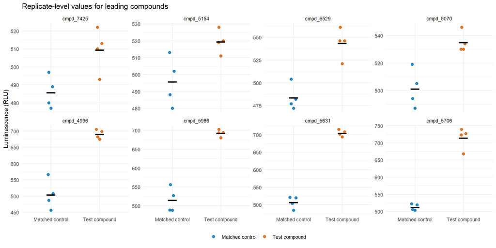

Figure 1: Technical replicate RLU values for compounds prioritised for diagnostic review. Black bars show group means.

```r
plate_long %>%
  filter(compound_id %in% diagnostic_candidates) %>%
  mutate(compound_id = fct_reorder(compound_id, rlu, .fun = mean)) %>%
  ggplot(aes(x = treatment_type, y = rlu, colour = treatment_type)) +
  geom_quasirandom(width = 0.10, size = 2.2, alpha = 0.85) +
  stat_summary(
    fun = mean,
    geom = "point",
    shape = 95,
    size = 9,
    colour = "black"
  ) +
  facet_wrap(~ compound_id, scales = "free_y", ncol = 4) +
  scale_colour_manual(values = c("#0072B2", "#D55E00")) +
  labs(
    title = "Replicate-level values for leading compounds",
    x = NULL,
    y = "Luminescence (RLU)",
    colour = NULL
  ) +
  theme_minimal(base_size = 11) +
  theme(legend.position = "bottom")
```

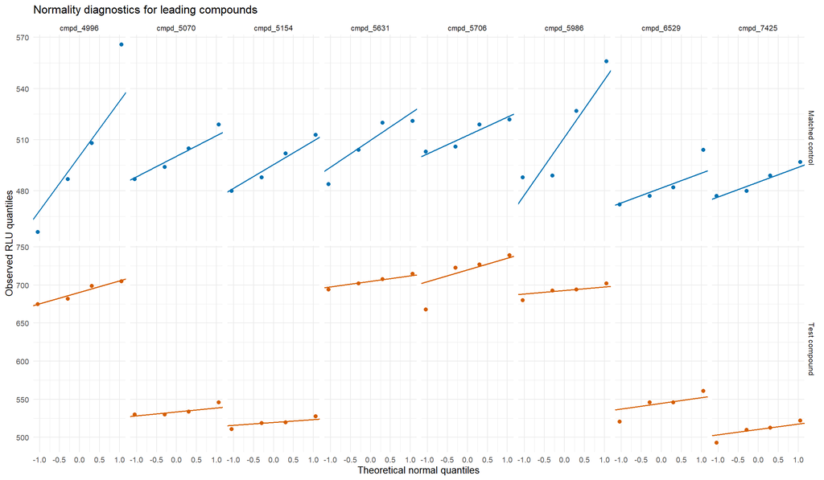

Figure 2: Normal Q-Q plots within each condition for compounds prioritised for diagnostic review.

```r
plate_long %>%
  filter(compound_id %in% diagnostic_candidates) %>%
  ggplot(aes(sample = rlu, colour = treatment_type)) +
  geom_qq(size = 1.7) +
  geom_qq_line(linewidth = 0.6) +
  facet_grid(treatment_type ~ compound_id, scales = "free") +
  scale_colour_manual(values = c("#0072B2", "#D55E00")) +
  labs(
    title = "Normality diagnostics for leading compounds",
    x = "Theoretical normal quantiles",
    y = "Observed RLU quantiles",
    colour = NULL
  ) +
  theme_minimal(base_size = 10) +
  theme(legend.position = "none")
```

```r
# Display the formal normality check only for the groups shown above.
normality_check %>%
  filter(compound_id %in% diagnostic_candidates) %>%
  mutate(shapiro_p = signif(shapiro_p, 3)) %>%
  pivot_wider(names_from = treatment_type, values_from = shapiro_p)
```

| compound_id | Matched control | Test compound |
| --- | --- | --- |
| cmpd_4996 | 0.838 | 0.5610 |
| cmpd_5070 | 0.845 | 0.0865 |
| cmpd_5154 | 0.842 | 0.8320 |
| cmpd_5631 | 0.314 | 0.9910 |
| cmpd_5706 | 0.314 | 0.1390 |
| cmpd_5986 | 0.303 | 0.6500 |
| cmpd_6529 | 0.309 | 0.5150 |
| cmpd_7425 | 0.664 | 0.6940 |

```r
n_diagnostic_groups <- normality_check %>%
  filter(compound_id %in% diagnostic_candidates) %>%
  nrow()

n_normality_flags <- normality_check %>%
  filter(compound_id %in% diagnostic_candidates, shapiro_p < 0.05) %>%
  nrow()

cat(
  "**Assumption assessment.**Of the", n_diagnostic_groups,
  "displayed compound-condition groups,", n_normality_flags,
  "had Shapiro-Wilk p < 0.05. Regardless of this count, n = 4 per group is",
  "too small to establish normality confidently. Welch's correction addresses",
  "unequal variance, while the Wilcoxon sensitivity test evaluates whether the",
  "main hit direction is supported without a normality assumption. The four",
  "wells are technical rather than biological replicates, so inference is",
  "restricted to this plate and donor."
)
```

**Assumption assessment.**Of the 16 displayed compound-condition groups, 0 had Shapiro-Wilk p < 0.05. Regardless of this count, n = 4 per group is too small to establish normality confidently. Welch’s correction addresses unequal variance, while the Wilcoxon sensitivity test evaluates whether the main hit direction is supported without a normality assumption. The four wells are technical rather than biological replicates, so inference is restricted to this plate and donor.

Across the 16 displayed compound-condition groups, no Shapiro–Wilk test gave p<0.05. However, each group contains only four technical replicates, so these tests have very limited power to detect non-normality. Non-significant results should not be interpreted as proof of normality. Welch’s t-test was used as the primary comparison because it tests the mean difference in continuous luminescence between each test compound and its matched control without assuming equal variances. Since the four wells are technical rather than biological replicates from a single donor and plate, inference is limited to this assay run and does not establish reproducible neuroprotection across donors.

#### 6.5.2.4 Multiple-testing results

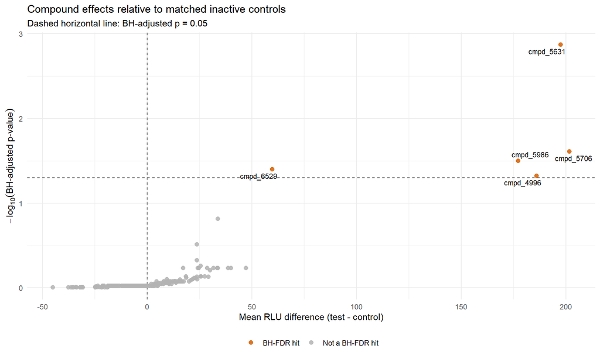

Figure 3: Mean test-control RLU difference and BH-adjusted significance for all 192 compounds.

```r
compound_tests %>%
  mutate(
    hit_status = if_else(hit, "BH-FDR hit", "Not a BH-FDR hit")
  ) %>%
  ggplot(aes(x = effect_rlu, y = -log10(fdr_bh))) +
  geom_hline(
    yintercept = -log10(0.05),
    linetype = 2,
    colour = "grey40"
  ) +
  geom_vline(xintercept = 0, linetype = 2, colour = "grey40") +
  geom_point(aes(colour = hit_status), size = 2.2, alpha = 0.85) +
  geom_text_repel(
    data = \(x) filter(x, hit),
    aes(label = compound_id),
    max.overlaps = Inf,
    size = 3,
    show.legend = FALSE
  ) +
  scale_colour_manual(
    values = c("BH-FDR hit" = "#D55E00", "Not a BH-FDR hit" = "grey70")
  ) +
  labs(
    title = "Compound effects relative to matched inactive controls",
    subtitle = "Dashed horizontal line: BH-adjusted p = 0.05",
    x = "Mean RLU difference (test - control)",
    y = expression(-log[10]("BH-adjusted p-value")),
    colour = NULL
  ) +
  theme_minimal(base_size = 11) +
  theme(legend.position = "bottom")
```

5 compounds appear to be statistically-significant according to the Benjamini-Hochberg (BH) procedure, namely cmpd_5631, cmpd_5706, cmpd_5986, cmpd_6529, cmpd_4996.

```r
hits_table <- compound_tests %>%
  filter(hit) %>%
  transmute(
    compound_id,
    target_gene = hgnc_symbol,
    target_entrez_id = target_enzyme,
    mechanism = action,
    mean_test_rlu = round(mean_test_rlu, 2),
    mean_control_rlu = round(mean_control_rlu, 2),
    difference_rlu = round(effect_rlu, 2),
    fold_change = round(fold_change, 3),
    p_value = signif(p_value, 3),
    fdr_bh = signif(fdr_bh, 3),
    wilcox_p_value = signif(wilcox_p_value, 3),
    wilcox_fdr_bh = signif(wilcox_fdr_bh, 3)
  )

if (nrow(hits_table) > 0) {
  hits_table
} else {
  # If no hit survives FDR, show candidates without mislabelling them as hits.
  compound_tests %>%
    filter(effect_rlu > 0) %>%
    slice_min(p_value, n = 10, with_ties = FALSE) %>%
    transmute(
      compound_id,
      target_gene = hgnc_symbol,
      mechanism = action,
      difference_rlu = round(effect_rlu, 2),
      fold_change = round(fold_change, 3),
      p_value = signif(p_value, 3),
      fdr_bh = signif(fdr_bh, 3),
      interpretation = "Nominal candidate; not an FDR hit"
    )
}
```

| compound_id | target_gene | target_entrez_id | mechanism | mean_test_rlu | mean_control_rlu | difference_rlu | fold_change | p_value | fdr_bh | wilcox_p_value | wilcox_fdr_bh |
| --- | --- | --- | --- | --- | --- | --- | --- | --- | --- | --- | --- |
| cmpd_5631 | LARGE1 | 9215 | agonist | 704.75 | 507.25 | 197.50 | 1.389 | 7.01e-06 | 0.00135 | 0.0152 | 0.486 |
| cmpd_5706 | RIT2 | 6014 | agonist | 714.25 | 512.50 | 201.75 | 1.394 | 2.57e-04 | 0.02470 | 0.0152 | 0.486 |
| cmpd_5986 | LRP6 | 4040 | agonist | 692.25 | 515.00 | 177.25 | 1.344 | 4.94e-04 | 0.03160 | 0.0152 | 0.486 |
| cmpd_6529 | MFNG | 4242 | antagonist | 543.50 | 483.75 | 59.75 | 1.124 | 8.31e-04 | 0.03990 | 0.0147 | 0.486 |
| cmpd_4996 | MAPK1 | 5594 | agonist | 690.25 | 504.25 | 186.00 | 1.369 | 1.24e-03 | 0.04770 | 0.0152 | 0.486 |

```r
if (n_hits == 0) {
  cat(
    "**Answer.** No compound met the pre-specified hit definition of a positive ",
    "effect with BH-adjusted p < 0.05. The displayed nominal candidates may be ",
    "prioritised for repeat screening, but this plate provides insufficient ",
    "evidence to call them statistically significant neuroprotective hits."
  )
} else {
  hit_names <- compound_tests %>%
    filter(hit) %>%
    pull(compound_id) %>%
    paste(collapse = ", ")

  cat(
    "**Answer.** ", n_hits,
    "compound(s) were associated with increased luminescence after BH-FDR ",
    "correction: ", hit_names, ". Of these,", n_wilcox_supported,
    "also had a one-sided Wilcoxon BH-adjusted p < 0.05. These are plate-level screening ",
    "hits rather than confirmed neuroprotective compounds because all four ",
    "observations per condition are technical replicates from one donor."
  )
}
```

**Answer.** 5 compound(s) were associated with increased luminescence after BH-FDR correction: cmpd_5631, cmpd_5706, cmpd_5986, cmpd_6529, cmpd_4996 . Of these, 0 also had a one-sided Wilcoxon BH-adjusted p < 0.05. These are plate-level screening hits rather than confirmed neuroprotective compounds because all four observations per condition are technical replicates from one donor.

5 compound(s) were associated with increased luminescence after BH-FDR correction: cmpd_5631, cmpd_5706, cmpd_5986, cmpd_6529, cmpd_4996. These are plate-level screening hits rather than confirmed neuroprotective compounds because all four observations per condition are technical replicates from one donor.

### 6.5.3 Question 3

*What are the mechanisms of action and targets of the compounds you identify in Q2?*

The compound dictionary supplies the HGNC target symbol, Entrez target ID and whether each test compound acts as an agonist or antagonist. Only compounds meeting the primary FDR hit definition are included below.

```r
mechanism_table <- compound_tests %>%
  filter(hit) %>%
  transmute(
    compound_id,
    target_gene = hgnc_symbol,
    target_entrez_id = target_enzyme,
    mechanism_of_action = action,
    difference_rlu = round(effect_rlu, 2),
    fold_change = round(fold_change, 3),
    fdr_bh = signif(fdr_bh, 3)
  ) %>%
  arrange(fdr_bh, desc(difference_rlu))

mechanism_table
```

| compound_id | target_gene | target_entrez_id | mechanism_of_action | difference_rlu | fold_change | fdr_bh |
| --- | --- | --- | --- | --- | --- | --- |
| cmpd_5631 | LARGE1 | 9215 | agonist | 197.50 | 1.389 | 0.00135 |
| cmpd_5706 | RIT2 | 6014 | agonist | 201.75 | 1.394 | 0.02470 |
| cmpd_5986 | LRP6 | 4040 | agonist | 177.25 | 1.344 | 0.03160 |
| cmpd_6529 | MFNG | 4242 | antagonist | 59.75 | 1.124 | 0.03990 |
| cmpd_4996 | MAPK1 | 5594 | agonist | 186.00 | 1.369 | 0.04770 |

Five compounds were identified as significantly associated with increased neuronal viability after MPP exposure following Benjamini-Hochberg correction (FDR < 0.05). Four compounds acted as agonists: cmpd_5631 targeted *LARGE1* (difference: 197.50 RLU; 1.389-fold increase; FDR = 0.00135), cmpd_5706 targeted *RIT2* (201.75 RLU; 1.394-fold; FDR = 0.02470), cmpd_5986 targeted *LRP6* (177.25 RLU; 1.344-fold; FDR = 0.03160), and cmpd_4996 targeted *MAPK1* (186.00 RLU; 1.369-fold; FDR = 0.04770). One compound, cmpd_6529, was an antagonist targeting *MFNG* (59.75 RLU; 1.124-fold; FDR = 0.03990).

## 6.6 Limitations and next steps

- Four wells per condition are **technical replicates**, not independent biological replicates.
- The screen was performed using dopaminergic neurons from **one healthy donor**.
- Only one compound concentration and one 24-hour time point were assessed.
- Luminescence is a proxy for viability and may reflect ATP content or metabolic state, not solely cell number.
- Candidate hits should be retested in independent plates, across a concentration range, with orthogonal assays such as live/dead imaging, neurite analysis, mitochondrial assays, or oxidative-stress readouts.
- Strong candidates should subsequently be tested in neurons derived from additional healthy donors and patients with Parkinson’s disease.

# 7 Clinical trial

## 7.1 Introduction

This section focuses on the results of a preliminary clinical trial for a potential new PD therapy.

### 7.1.1 Background

One of the hit compounds from the PD drug screen is already approved for other indications in Australia. This means that it could more easily be applied for PD treatment than an entirely new compound, if effective in treating PD. A preliminary clinical trial was run to test the efficacy of this drug in treating PD motor symptoms, compared to the standard of care L-DOPA.

16 PD patients were enrolled in the trial and randomly assigned to new compound or L-DOPA groups. Four patients in each trial were additionally randomly assigned to a daily exercise routine, as regular exercise is known to help manage PD motor symptoms.

The effect of each drug on motor symptoms was tested using a smart watch, which measured patients’ vertical orientation (in degrees off-axis) while walking during their normal daily activities. Zero degrees indicates an entirely vertical orientation. Patients’ orientation was measured every second for 700 seconds. Patients’ orientation provides a measure of their balance and the stability of their gait.

### 7.1.2 Aims

This section has three main aims:

1. To determine a suitable summary statistic of the orientation data that serves as a proxy for patients’ balance and gait stability over the 700 seconds of measurement.
2. To obtain preliminary data on effect of the new drug on balance and gait stability in PD patients, particularly whether it may provide superior management of motor symptoms compared to the current standard of care.
3. To determine the effect of the exercise routine and age on balance and gait stablity, and how they affect the relationship between treatment (standard of care vs new compound) and gait stability.

### 7.1.3 The dataset

The gait dataset contains the data from the clinical trial and can be viewed with the below code.

```r
gait_data
```

| donorid | treatment | age | exercise | 1_secs | 2_secs | 3_secs | 4_secs | 5_secs | 6_secs | 7_secs | 8_secs | 9_secs | 10_secs | 11_secs | 12_secs | 13_secs | 14_secs | 15_secs | 16_secs | 17_secs | 18_secs | 19_secs | 20_secs | 21_secs | 22_secs | 23_secs | 24_secs | 25_secs | 26_secs | … |
| --- | --- | --- | --- | --- | --- | --- | --- | --- | --- | --- | --- | --- | --- | --- | --- | --- | --- | --- | --- | --- | --- | --- | --- | --- | --- | --- | --- | --- | --- | --- |
| d003 | New compound | 64.39234 | y | 0.7594029 | 0.8091884 | 1.444452 | 3.7143524 | -1.7337919 | -1.4663500 | -6.231979 | -1.4495913 | 5.2091205 | -3.90441527 | -1.809094 | -0.3120759 | 0.3798000 | -2.78368056 | 2.4419325 | -2.957128 | 1.0085234 | 2.271056 | 6.67653928 | -4.5914267 | -8.6106447 | -7.4267571 | -0.6189723 | 5.9397979 | -0.07361178 | 1.9668504 | … |
| d015 | New compound | 64.47713 | n | 11.7977903 | 3.9082139 | 6.683022 | 14.9390819 | 0.5287381 | 2.5219853 | -7.960596 | 0.6968332 | 12.9667626 | -9.61991513 | 1.525434 | -4.2460131 | -16.7583571 | -6.02965692 | 1.2005935 | 5.605456 | -0.1837601 | 11.998236 | 1.45942589 | -9.9742209 | -11.5225490 | 7.2344686 | -5.8046849 | 3.0445750 | -11.99805335 | -4.7376671 | … |
| d019 | New compound | 64.23408 | y | 2.6792586 | -3.9242798 | -1.891468 | 0.5823181 | 3.2836495 | 0.6457318 | 3.220898 | -2.6997412 | -0.5908903 | -0.05684456 | -1.474931 | 3.6646829 | -4.2689085 | -1.71298986 | -2.7007492 | 2.569470 | 1.2072077 | -2.202789 | 2.99448060 | -3.1744666 | -1.2867177 | 1.5502714 | 1.2222373 | -1.6218230 | -1.27406642 | -2.2531882 | … |
| d040 | L-DOPA control | 66.22810 | n | -5.8987574 | 2.3941025 | -4.473918 | 11.3701066 | -15.8229676 | -0.4515483 | -11.668870 | -2.4903950 | -9.3458353 | 22.80135421 | 9.651842 | 4.2538989 | 4.8693032 | -0.04027578 | -0.9289933 | 4.110292 | 3.5655577 | -2.458179 | 10.39717617 | 3.9337820 | 1.4569855 | -11.2320902 | -0.5961251 | -0.5308358 | 4.21658971 | 10.7295199 | … |
| d079 | New compound | 69.81401 | y | 1.3341791 | -5.2977909 | -8.876371 | 11.8106468 | -17.0064515 | 3.9768484 | 11.817539 | -6.1147903 | 2.3567014 | 0.42695143 | 14.326908 | 0.3566726 | 0.8714104 | -11.78702259 | 6.3130524 | 5.340413 | -4.4742584 | -1.528784 | -6.06191216 | 6.0007372 | 9.6957870 | 20.4830149 | 10.8170828 | 1.9979603 | -11.76245263 | -2.9416506 | … |
| d086 | L-DOPA control | 81.85784 | y | 12.7096913 | -6.6434589 | 8.828639 | 13.2858312 | 0.8717808 | 4.0281744 | 7.906565 | 10.5993844 | 13.8781105 | -12.63674623 | 23.041844 | 16.4949800 | 9.7576285 | -5.85799465 | -18.6713046 | 3.096822 | 6.7747533 | -1.758198 | 9.68296323 | 19.6894839 | 10.1600867 | -0.3272624 | 16.7882560 | -0.7847388 | 1.24558154 | -1.4944639 | … |
| d089 | L-DOPA control | 69.22492 | n | -20.0969653 | -0.5958810 | -11.514396 | 4.7593059 | 6.2791093 | -17.9387319 | 13.798292 | -12.9286571 | -14.0288992 | 21.69540691 | -8.641547 | 18.1421204 | -7.2559683 | -1.40165993 | -2.3506302 | 21.118356 | -1.8240832 | 8.247729 | 6.24502198 | -12.7868667 | 0.8752379 | -3.4501722 | 5.8680537 | 14.3434071 | -0.53512229 | 18.5033248 | … |
| d136 | New compound | 82.79132 | n | -10.7958956 | -2.1126718 | -20.533257 | -31.8329600 | 16.8380251 | -27.5888827 | -1.772762 | -2.2991442 | 28.1993860 | -3.54373260 | -4.254243 | 2.2353432 | 9.3651737 | 27.78752869 | -9.2818202 | 7.007747 | 21.4037944 | -1.468992 | -0.78355974 | -6.3829609 | -2.9432225 | -2.5732958 | 2.2404529 | 2.5949502 | 4.26739024 | -13.4448010 | … |
| d141 | L-DOPA control | 85.58216 | n | 3.8763736 | 12.2646621 | -3.105284 | 12.0160723 | -28.5246272 | -6.6021084 | -1.802699 | -14.3938571 | -16.5603477 | -0.35924435 | -19.384165 | 4.2185015 | -6.8394837 | -2.97348670 | -5.3286930 | -5.042841 | -7.4501223 | 4.348952 | -24.21672562 | 5.9378330 | -10.7342920 | -5.3574845 | -20.7637490 | -2.5043934 | 9.88271304 | 11.1952905 | … |
| d143 | New compound | 76.03973 | y | -0.6999499 | 8.5176469 | -3.113306 | -3.5790775 | -2.8534489 | -1.3915283 | 2.434078 | -1.4888545 | -2.8915768 | -4.17980483 | 7.455447 | -6.8001768 | -1.5343891 | -7.03105876 | -0.9785990 | 5.647024 | -2.9255069 | 2.810300 | -0.05591304 | 6.1426923 | -9.0885715 | -8.3947363 | -8.2277956 | 3.2606493 | 3.50558380 | 7.4047203 | … |

[output cut: 6 more lines]

The gait_data dataset contains information on the 16 PD patients enrolled in the trial, including their id (donorid column) treatment group (treatment column; L-DOPA control or new compound), age (age column; in years), and whether they were assigned to the exercise routine (exercise column; y = yes, n = no). It also contains measurements of the patients’ vertical orientation (degrees off-axis) for each of the 700 measurements at 1-second intervals (*_secs columns).

## 7.2 Data analysis

### 7.2.1 Tidy up the gait data

First, check if there are any missing values in the gait data.

```r
# return the number of NAs in gait_data
is.na(gait_data) %>% sum()
```

```
[1] 0
```

There are no missing values, so the raw data can now be formatted in a way suitable for plotting and further analysis.

```r
# re-format the gait data
gait_long <- gait_data %>%
  # convert orientation columns into long format (two columns for timepoint and orientation at that timepoint)
  pivot_longer(
    cols = ends_with('_secs'),
    names_to = 'timepoint_secs',
    values_to = 'orientation_deg') %>%
  # change timepoint to numeric format
  mutate(timepoint_secs = timepoint_secs %>%
           str_remove('_secs') %>%
           as.numeric())
```

We can now view the dataset in long format. Each patient should have 700 rows, one for each timepoint measured.

```r
# view the formatted dataset
gait_long
```

| donorid | treatment | age | exercise | timepoint_secs | orientation_deg |
| --- | --- | --- | --- | --- | --- |
| d003 | New compound | 64.39234 | y | 1 | 0.759402854 |
| d003 | New compound | 64.39234 | y | 2 | 0.809188428 |
| d003 | New compound | 64.39234 | y | 3 | 1.444451808 |
| d003 | New compound | 64.39234 | y | 4 | 3.714352361 |
| d003 | New compound | 64.39234 | y | 5 | -1.733791866 |
| d003 | New compound | 64.39234 | y | 6 | -1.466350015 |
| d003 | New compound | 64.39234 | y | 7 | -6.231979274 |
| d003 | New compound | 64.39234 | y | 8 | -1.449591303 |
| d003 | New compound | 64.39234 | y | 9 | 5.209120517 |
| d003 | New compound | 64.39234 | y | 10 | -3.904415267 |

[output cut: 9990 more lines]

```r
# check that each of 16 patients have 700 columns
gait_long %>%
  count(donorid, name = "n(timepoints)") %>%
  count(`n(timepoints)`, name = "n(patients)")
```

| n(timepoints) | n(patients) |
| --- | --- |
| 700 | 16 |

The first output confirms that we maintain the donorid, treatment, age, and exercise columns, that the orientation data has been converted into two columns (timepoint in seconds and orientation at that timepoint in degrees off-axis), and that the new timepoint column is numeric. The second output confirms that the data includes all 16 patients with 700 rows each.

### 7.2.2 Determine a suitable measure of balance gait stability

#### 7.2.2.1 Visualisation of gait data

Before we can determine a measure of balance and gait, we must visualise the data. Data for each participant can be plotted as a line graph, showing the patient’s orientation over the 700 seconds of measurement.

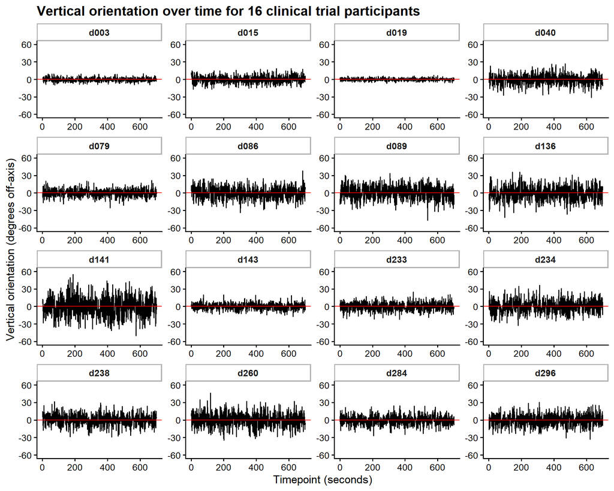

```r
# plot orientation against timepoint for each patient
ggplot(data = gait_long, aes(x = timepoint_secs, y = orientation_deg)) +
  geom_line() + # plot a line graph
  facet_wrap(~donorid, axes = 'all') + # make a separate plot for each patient
  geom_hline(yintercept = 0, colour = 'red', linewidth = 0.5) + # add reference line at 0 degrees (which represents standing exactly upright)
  scale_y_continuous(limits = c(-60, 60)) +
  labs(title = 'Vertical orientation over time for 16 clinical trial participants',
       x = 'Timepoint (seconds)',
       y = 'Vertical orientation (degrees off-axis)')
```

These plots show that each patient’s vertical orientation varies many times over the 700 seconds measured, roughly oscillating around zero (perfectly upright). Some patients show more extreme variability in orientation than others, and we can assume that the amount of variability is indicative of their balance and gait stability. For example, d019 shows the least variability, with their orientation remaining within 10 degrees off-axis, suggesting a fairly stable gait and good balance. Meanwhile, d141 shows the greatest variability, reaching up to 60 degrees off-axis, suggesting very poor balance and an unstable gait.

#### 7.2.2.2 Calculate various descriptive statistics each patient

It would appear from the above plots that some measure of spread for a patient’s orientation over the time measured would be a suitable proxy for their balance and gait stability. Various measures of spread could be suitable, including mean or median absolute value, standard deviation (SD), root mean square (RMS), range, or interquartile range (IQR). These values are calculated for each patient below. Also calculated are the mean and median orientation for each patient, which should equal approximately zero if the patient’s orientation oscillates around zero degrees (as it would appear from the graph), or a non-zero value if the patient is systematically leaning to one side.

```r
# calculate various summary statistics for each patient:
gait_summary <- gait_long %>% summarise(
   # calculate mean and median for a measure of centre (from plots, expected to be approximately zero degrees)
  mean = mean(orientation_deg),
  median = median(orientation_deg),
  # calculate mean and median absolute values as a measure of spread
  mean_abs = mean(abs(orientation_deg)),
  median_abs = median(abs(orientation_deg)),
  # calcualte range and interquartile range as measures of spread
  range = max(orientation_deg) - min(orientation_deg),
  IQR = IQR(orientation_deg),
  # calculate standard deviation and root mean square as measures of spread
  sd = sd(orientation_deg),
  rms = sqrt(mean(orientation_deg ^2)),
  # calculate these separately for each patient
  .by = donorid
) %>%
  # join summary stats onto the treatment, age, and exercise information from gait_data by the shared donor.id column
  left_join(
    select(gait_data, donorid, treatment, age, exercise),
    .,
    by = "donorid"
  ) %>%
  # make treatment and exercise factors (for plotting later)
  mutate(exercise = as.factor(exercise),
         treatment = as.factor(treatment))

# inspect the output data, summarising each patient's orientation over the 700 seconds of measurement
gait_summary
```

| donorid | treatment | age | exercise | mean | median | mean_abs | median_abs | range | IQR | sd | rms |
| --- | --- | --- | --- | --- | --- | --- | --- | --- | --- | --- | --- |
| d003 | New compound | 64.39234 | y | -0.21842977 | -0.23144187 | 2.669030 | 2.326423 | 19.49794 | 4.580858 | 3.374886 | 3.379541 |
| d015 | New compound | 64.47713 | n | -0.07613260 | -0.44536599 | 5.165834 | 4.218798 | 35.56131 | 8.438131 | 6.490199 | 6.486009 |
| d019 | New compound | 64.23408 | y | -0.11837100 | -0.17049048 | 1.884097 | 1.646781 | 14.32130 | 3.286270 | 2.346471 | 2.347781 |
| d040 | L-DOPA control | 66.22810 | n | -0.18280464 | -0.18392592 | 6.879792 | 5.472424 | 58.38844 | 10.922377 | 8.875597 | 8.871139 |
| d079 | New compound | 69.81401 | y | 0.05245747 | 0.26330020 | 5.527192 | 4.785130 | 47.61277 | 9.525085 | 6.887988 | 6.883266 |
| d086 | L-DOPA control | 81.85784 | y | -0.09646138 | 0.10409497 | 8.390781 | 7.190004 | 71.64993 | 14.177272 | 10.525916 | 10.518837 |
| d089 | L-DOPA control | 69.22492 | n | 0.77642991 | 0.21291171 | 9.539770 | 8.222379 | 80.78955 | 17.131082 | 11.793894 | 11.811015 |
| d136 | New compound | 82.79132 | n | -0.59452867 | -0.80964360 | 9.484387 | 7.620846 | 78.02595 | 15.159441 | 12.000317 | 12.006471 |
| d141 | L-DOPA control | 85.58216 | n | -0.91357839 | -1.40457291 | 13.824613 | 11.769030 | 110.99736 | 23.751312 | 17.259851 | 17.271696 |
| d143 | New compound | 76.03973 | y | 0.14722656 | 0.05521778 | 4.530494 | 3.757751 | 37.07704 | 7.481530 | 5.706779 | 5.704602 |

[output cut: 6 more lines]

From this data, we can first evaluate whether patients’ orientation typically oscillates around a mid-point of zero degrees. Measures for this include the mean and median orientation being approximately zero and the SD and RMS being approximately equal for each patient.

```r
# evaluate the distribution of the mean and median orientation
message("summary of mean orientation")
summary(gait_summary$mean)
```

```
    Min.  1st Qu.   Median     Mean  3rd Qu.     Max.
-0.91358 -0.19171 -0.08630 -0.05416  0.07615  0.77643
```

```r
message("\nsummary of median orientation")
summary(gait_summary$median)
```

```
    Min.  1st Qu.   Median     Mean  3rd Qu.     Max.
-1.40457 -0.20563 -0.04296 -0.08209  0.26721  0.49250
```

```r
# check if patients' SD and RMS of orientation are approximately equal

message("\nsummary of difference between SD and RMS")
(gait_summary$sd - gait_summary$rms) %>% summary()
```

```
      Min.    1st Qu.     Median       Mean    3rd Qu.       Max.
-0.0171208 -0.0021457  0.0023968  0.0001814  0.0045242  0.0086692
```

From the above summaries, we can conclude that patients’ mean and median orientations are typically within 1 degree of zero and usually even less, indicating that their orientation varies around a midpoint of verticality. Additionally, patients’ RMS and SD of orientation are very similar, with the largest difference between them being only 0.017 degrees, which also supports patients’ orientation oscillating around zero degrees. Since this analysis is only exploratory, statistical testing was not performed to confirm this.

For a measure of spread to use as a proxy for patients’ balance and gait smoothness, we considered mean and median absolute values, range, IQR, SD, and RMS of their orientation measurements overall the 700 seconds measured. While measurements of gait smoothness or balance in the literature are usually more complex than the one used here, the RMS is often used (e.g. RMS centre of mass or pressure). Since SD and RMS were almost identical and SD is more widely understood and reported, we took the SD of patients’ orientation over time (sd(orientation)) as a proxy for balance and gait smoothness. Higher sd(orientation) will indicate poorer balance and gait stability for a patient.

#### 7.2.2.3 Confirm that the chosen measure of balance and gait stability is appropriate for the data

SD is most appropriate as a measure of spread when there are minimal outliers and the data largely follows a normal distribution. This can first be investigated visually using a histogram of the orientation measurements for each patient.

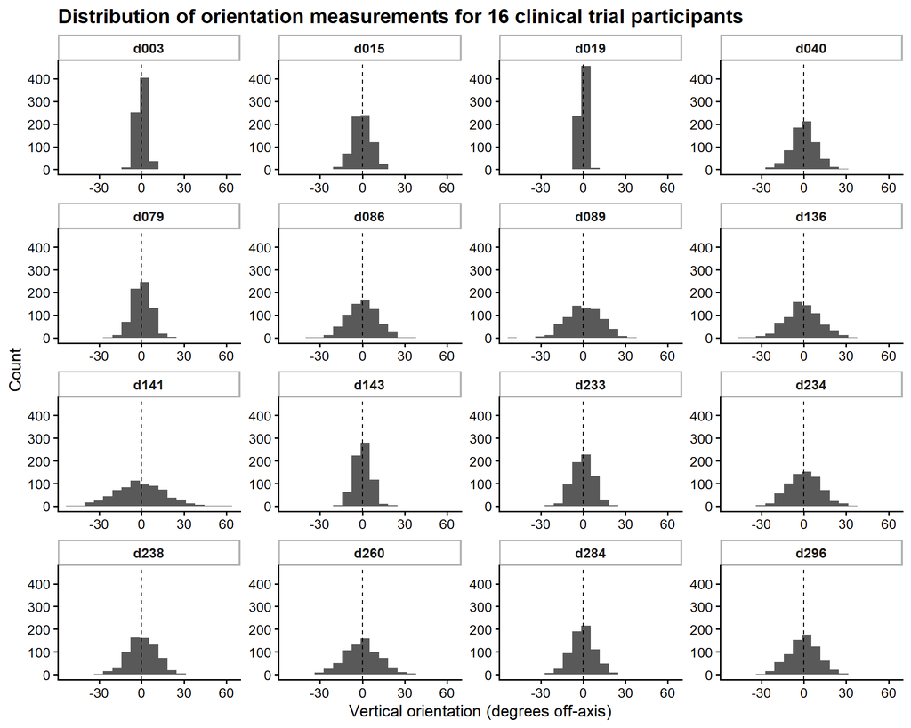

```r
# plot a histogram of orientation for each patient
ggplot(data = gait_long, aes(x = orientation_deg)) +
  geom_histogram(bins = 18) + # plot a histogram - bins decided with Rice's rule
  # make a separate plot for each patient
  facet_wrap(~donorid, axes = 'all') +
  # add a reference line at 0 degrees - the expected centre
  geom_vline(xintercept = 0, colour = 'black', linetype = 2, linewidth = 0.5) +
  labs(title = "Distribution of orientation measurements for 16 clinical trial participants", x = "Vertical orientation (degrees off-axis)", y = "Count")
```

It appears from the histograms that each patient’s data is roughly symmetrical. The normality can be tested using QQ plots and a Shapiro-Wilk test.

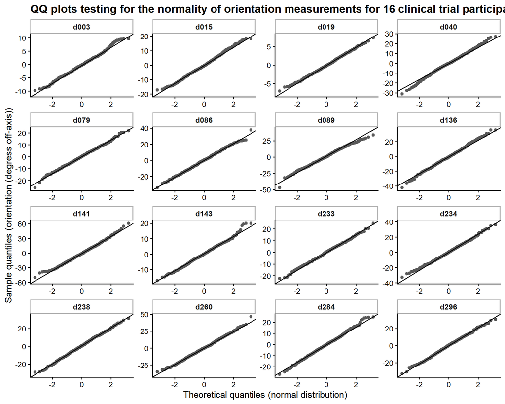

```r
# plot a QQ plot of orientation measurements for each patient
ggplot(data = gait_long, aes(sample = orientation_deg)) +
  geom_qq(colour = 'grey35') + # plot a qq plot with a reference normal distribution
  geom_qq_line() + # add a reference line
  # make a separate plot for each patient
  facet_wrap(~donorid, scales = "free", axes = 'all') +
  labs(title = "QQ plots testing for the normality of orientation measurements for 16 clinical trial participants", x = 'Theoretical quantiles (normal distribution)', y = 'Sample quantiles (orientation (degress off-axis))')
```

A Shapiro test tests for the null hypothesis of normally distributed data.

```r
# run shapiro tests on the orientation data
gait_long %>%
  group_by(donorid) %>% # run a test for each patient
  shapiro_test(orientation_deg) %>%
  ungroup()
```

| donorid | variable | statistic | p |
| --- | --- | --- | --- |
| d003 | orientation_deg | 0.9959404 | 0.06648629 |
| d015 | orientation_deg | 0.9967095 | 0.16107736 |
| d019 | orientation_deg | 0.9982692 | 0.71816392 |
| d040 | orientation_deg | 0.9968165 | 0.18157663 |
| d079 | orientation_deg | 0.9984415 | 0.79761495 |
| d086 | orientation_deg | 0.9983828 | 0.77125547 |
| d089 | orientation_deg | 0.9964224 | 0.11621192 |
| d136 | orientation_deg | 0.9981254 | 0.64900755 |
| d141 | orientation_deg | 0.9971986 | 0.27510037 |
| d143 | orientation_deg | 0.9962508 | 0.09536850 |

[output cut: 6 more lines]

In the QQ plots, the points follow the reference lines quite well, suggesting normal orientation data within each patient, although the divergence at the tails suggest some minor departure from normality. The Shapiro-Wilk tests generally yield p > 0.05, which does not provide evidence against the null hypothesis that the data is normal. While the p-values are quite low for a few patients (the lowest being 0.07 for d003), the fact that the Shapiro-Wilk tests and QQ plots are consistent with normal data for the majority of the 16 patients suggests that sd(orientation) is an appropriate proxy for balance and gait smoothness.

### 7.2.3 Comparing the new compound to standard of care

#### 7.2.3.1 Visualise the distribution of orientation standard deviation for each group

First, we can visually explore the distribution of sd(orientation) between treatment groups with a box plot and beeswarm plot.

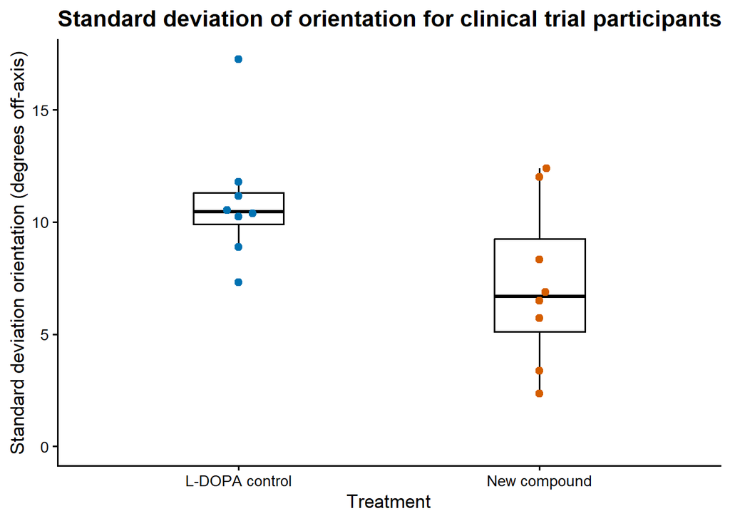

```r
# Make boxplot + beeswarm of standard deviation orientation for patients in each group; colour by group
ggplot(data = gait_summary, aes(x = treatment, y = sd, colour = treatment)) +
  geom_boxplot(width = 0.3, colour = 'black') + # add boxplot
  geom_beeswarm(cex = 2.5, size = 2, preserve.data.axis = TRUE) + # add individual points as beeswarm
  scale_colour_manual(values = treatment_colours) +
  scale_y_continuous(limits = c(0, NA)) +
  theme(legend.position = 'none') +
  labs(title = 'Standard deviation of orientation for clinical trial participants',
       x = 'Treatment', y = 'Standard deviation orientation (degrees off-axis)')
```

From the boxplots, it appears that the group treated with the new compound has a lower sd(orientation) over the 700 seconds, indicating a smoother gait and better balance, but this must be checked with statistical tests. It also appears that the new compound group has a greater variance in sd(orientation) than the control group.

An independent samples t-test or a Wilcoxon rank-sum test (Mann-Whitney U test) would be appropriate for comparing the two groups, depending on whether the assumptions of a t-test are met.

#### 7.2.3.2 Address the assumptions of a t-test

1. Continuous outcome and two predictor groups: This assumption is met. The predictor, treatment group, is binary (L-DOPA control or new compound). The outcome variable, sd(orientation), is a continuous variable.
2. Independent observations: This assumption is likely met in the study design, as presumably no patient’s measurements should affect another’s. We can make sure that each patient only appears in one group by checking that each donor id only appears once (see below). We can also assume that the trial coordinators used appropriate sampling techniques to ensure that this assumption is met (e.g. to avoid clustering of participants or non-random sampling).

```r
# check that each donor id only appears only once (code outputs zero if this is the case)
# this should guarantee that each donor id only appears in one group
duplicated(gait_summary$donorid) %>% sum
```

```
[1] 0
```

3. Normally distributed outcome variable in each group: This can be tested with a QQ plot and a Shapiro-Wilk test.

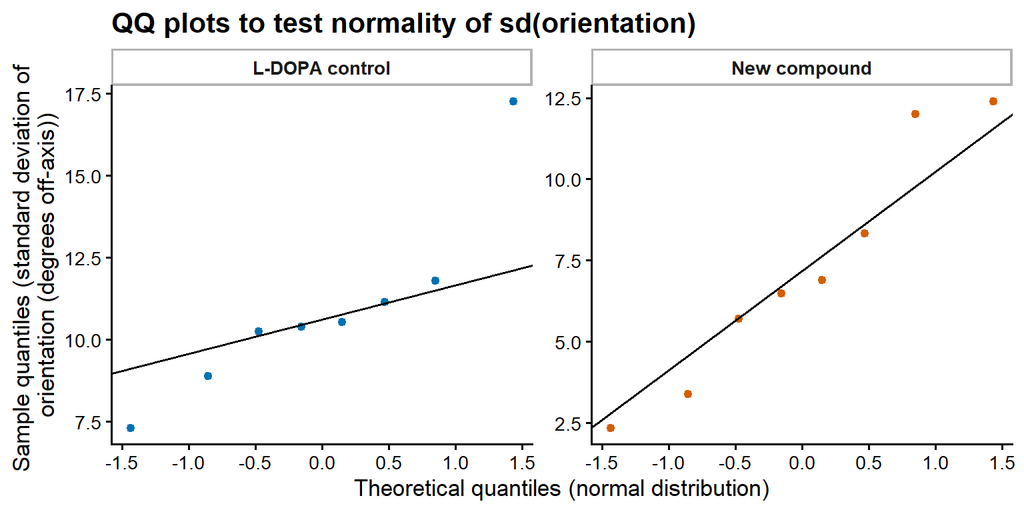

```r
# make a qq plot showing the distribution of the outcome variable in each treatment group against a reference normal distribution
ggplot(data = gait_summary, aes(sample = sd, colour = treatment)) +
  geom_qq() + # plot sample vs theoretical quantiles
  geom_qq_line(colour = 'black') + # add a reference line
  facet_wrap(~treatment, scales = 'free', axes = 'all') + # make separate plots for each treatment group
  scale_colour_manual(values = treatment_colours) +
  theme(legend.position = 'none') +
  labs(title = 'QQ plots to test normality of sd(orientation)',
         x = 'Theoretical quantiles (normal distribution)',
         y = 'Sample quantiles (standard deviation of \norientation (degrees off-axis))')
```

The QQ plot suggests that the standard deviation of orientation does not form a normal distribution for either group, since the points do not seem to closely follow the reference line representing a normal distribution. However, this is difficult to see since the sample size is very small. A Shapiro test quantitatively tests the assumption that the outcome follows a normal distribution. The null hypothesis tested is that the data follows a normal distribution.

```r
# perform a shapiro test to check the assumption that the sd(orientation) in each group follows a normal distribution (null hypothesis)
gait_summary %>%
  group_by(treatment) %>% # to perform a separate test for each treatment group
  shapiro_test(sd) %>% # perform Shapiro test on sd(orientation) values
  ungroup()
```

| treatment | variable | statistic | p |
| --- | --- | --- | --- |
| L-DOPA control | sd | 0.8552750 | 0.1076887 |
| New compound | sd | 0.9345607 | 0.5584771 |

A Shapiro-Wilk normality test on the outcome variable (standard deviation of orientation) yields p = 0.11 for the L-DOPA control group and 0.56 for the new compound group. In both groups, this means we fail to reject the null hypothesis that the data follows a normal distribution. However, small sample sizes (as seen here) can make the Shapiro test lose power to detect a departure from normality. Because of this, and the QQ plots not appearing normal, we proceeded with a non-parametric Wilcoxon rank-sum test (Mann-Whitney U test) to test for a difference between treatment groups, which does not assume normality of the outcome variable. No other assumptions need to be tested for this.

It is to be noted that since it is possible to transform data to make the outcome variable normal, we attempted various transformations but none substantially improved the normality of the data. An example of this - using a square root transformation on the outcome data - is shown below. The QQ plot does not look much closer to normality than the raw data, and while the Shapiro test p-values are slightly larger, it is still safest to run a non-parametric test since the small sample size could be distorting results. We substituted various transformations into the below code and none of them were particularly successful; many made the data appear more normal for one group but not the other or largely normalised the data but left major outliers.

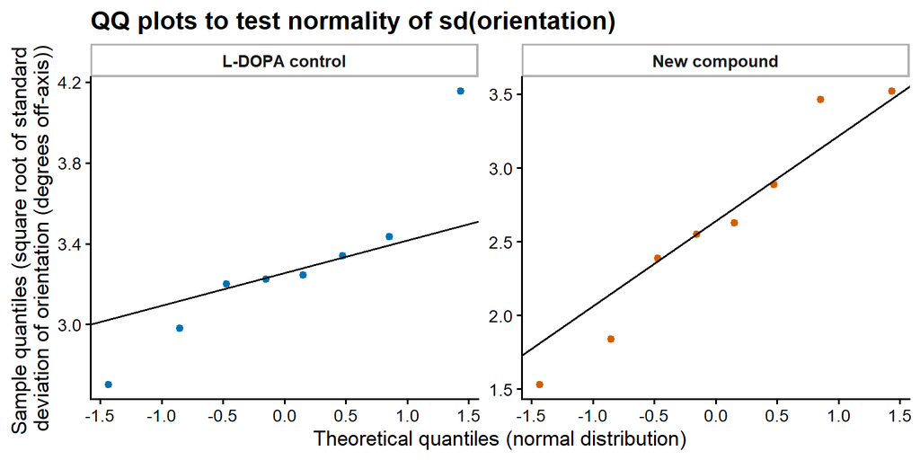

```r
# make a QQ plot of transformed outcome data
gait_summary %>%
  mutate(trans_sd = sqrt(sd)) %>%  # make a column of transformed sd(orientation) data
  # make a qq plot showing the distribution of the outcome variable in each treatment group against a reference normal distribution
  ggplot(aes(sample = trans_sd, colour = treatment)) +
  geom_qq() + # plot sample vs theoretical quantiles
  geom_qq_line(colour = 'black') + # add a reference line
  facet_wrap(~treatment, scales = 'free', axes = 'all') + # make separate plots for each treatment group
  scale_colour_manual(values = treatment_colours) +
  theme(legend.position = 'none') +
  labs(title = 'QQ plots to test normality of sd(orientation)',
       x = 'Theoretical quantiles (normal distribution)',
       y = 'Sample quantiles (square root of standard \ndeviation of orientation (degrees off-axis))')
```

```r
# run a Shapiro test for normality of transformed sd(orientation) data
gait_summary %>%
  mutate(trans_sd = sqrt(sd)) %>%  # make a column of transformed sd(orientation) data
  # run a separate test for each treatment group
  group_by(treatment) %>%
  # run the Shapiro test
  shapiro_test(trans_sd) %>%
  ungroup()
```

| treatment | variable | statistic | p |
| --- | --- | --- | --- |
| L-DOPA control | trans_sd | 0.8951215 | 0.2609426 |
| New compound | trans_sd | 0.9495634 | 0.7068288 |

Although we will proceed with a Wilcoxon rank-sum test for our main test of differences between groups, we can check the fourth assumption of a standard t-test (for consideration later on).

4. Equal variances between groups: From the IQR of the boxplots shown above, it appears that the new compound group has a substantially larger variance than the L-DOPA control group. This can be quantified using a Levene test, which is suitable here as the groups are independent. Although the sd(orientation) data does not appear skewed on the box and jitter plot, this is difficult to tell due to the small sample size and there is one substantial outlier; therefore, the Brown-Forsythe variant, which uses median instead of mean, was used. The null hypothesis is that the variance of each group is equal.

```r
# calculate the variance of each group
gait_summary %>%
  summarise(variance = var(sd),
            .by = treatment)
```

| treatment | variance |
| --- | --- |
| New compound | 13.173043 |
| L-DOPA control | 8.448025 |

```r
# perform Levene test (Brown-Forsythe variant) for equal variances between treatment groups
gait_summary %>%
  levene_test(sd ~ as.factor(treatment), center = median)
```

| df1 | df2 | statistic | p |
| --- | --- | --- | --- |
| 1 | 14 | 0.7309306 | 0.4069749 |

The Levene test does not provide evidence against the null hypothesis that groups have equal variance (p = 0.41), but like the Shapiro test, this test also has limited statistical power when the sample size is small. Considering this fact, and that the variances appear quite different (13.2 for new compound vs 8.4 for control), we are unsure whether the groups truly have different variances.

#### 7.2.3.3 Quantify the difference between treatment groups

As discussed above, a Wilcoxon rank-sum test will be used to obtain the most confident estimate of the difference in sd(orientation), as a measure of balance and gait stability, between treatment groups. It does not test for a difference in group means, rather for a difference in the general distribution of the outcome between groups.

```r
# run a Wilcoxon rank-sum/Mann-Whitney U-test comparing the distribution of sd(orientation) between the two treatment groups
# by default, two-sided and unpaired
gait_summary %>%
  wilcox_test(sd ~ treatment)
```

|  | .y. | group1 | group2 | n1 | n2 | statistic | p |
| --- | --- | --- | --- | --- | --- | --- | --- |
| 1 | sd | L-DOPA control | New compound | 8 | 8 | 49 | 0.08298368 |

This yields a p-value of 0.083, which does not provide any strong evidence that there is a difference in distribution in sd(orientation), as a proxy for gait smoothness, between the L-DOPA control and new compound treatment groups. This p-value is non-significant according to the traditional threshold of p = 0.05, but is nearing this value, but considering p-values as a continuum, may provide some weak support for a difference between groups. It is also important to consider that the very small sample size (n = 8 per group) may also veil an effect. While the Wilcoxon rank=sum test did not detect a substantial difference in sd(orientation) between groups, accounting for covariates may reveal an effect, which will be tested below.

### 7.2.4 Consider covariates of age and exercise on the effect of treatment

#### 7.2.4.1 Fit a linear model for the effect of treatment on gait

A linear model is the most common way to effect the relationship between a continuous outcome variable and a categorical predictor variable while considering covariates. For a binary predictor like in our data and no covariates, a linear model is equivalent to an unpaired, two-tailed t-test with equal variances. As discussed above, our data may subvert the t-test assumptions of normality of the outcome variable within each group and equal variances for the outcome variable between groups.

Nonetheless, we fitted a linear model for two reasons:

1. As a complementary, but likely less robust and accurate, approach to the above Wilcoxon rank-sum test to test for a difference between treatment groups.
2. To test the effects of covariates on the realtionship between treatment and gait, while keeping the potentially violated assumptions in mind.

First, we ran a simple linear model without any covariates. The null hypothesis for a linear model is that the slope of the regression line is zero; for simple linear regression with a binary variables, this is equivalent to the null hypothesis of a t-tset that group means are equal.

```r
# fit a linear model for the effect of treatment on sd(orientation)
lm(sd ~ treatment, data = gait_summary) %>%
  summary()
```

```
Call:
lm(formula = sd ~ treatment, data = gait_summary)

Residuals:
    Min      1Q  Median      3Q     Max
-4.8432 -1.6292 -0.4847  0.9215  6.3159

Coefficients:
                      Estimate Std. Error t value Pr(>|t|)
(Intercept)             10.944      1.162   9.414 1.96e-07 ***
treatmentNew compound   -3.754      1.644  -2.284   0.0385 *
---
Signif. codes:  0 '***' 0.001 '**' 0.01 '*' 0.05 '.' 0.1 ' ' 1

Residual standard error: 3.288 on 14 degrees of freedom
Multiple R-squared:  0.2714,    Adjusted R-squared:  0.2194
F-statistic: 5.215 on 1 and 14 DF,  p-value: 0.03853
```

The p-value for the effect of treatment, 0.039, provides some evidence against the null hypothesis that the groups have the same mean sd(orientation), suggesting that there is a difference between treatment groups. This would imply that the new treatment is associated with better balance and gait stability. However, we must remember that p was higher in the Wilcoxon rank-sum test, which is likely more accurate and appropriate for the data.

#### 7.2.4.2 Investigate the effect of exercise regime on the relationship between gait and treament

Now we can test the effects of covariates on the relationship between treatment and gait. First, we can visualise the effect of exercise on the relationship between treatment and gait smoothness.

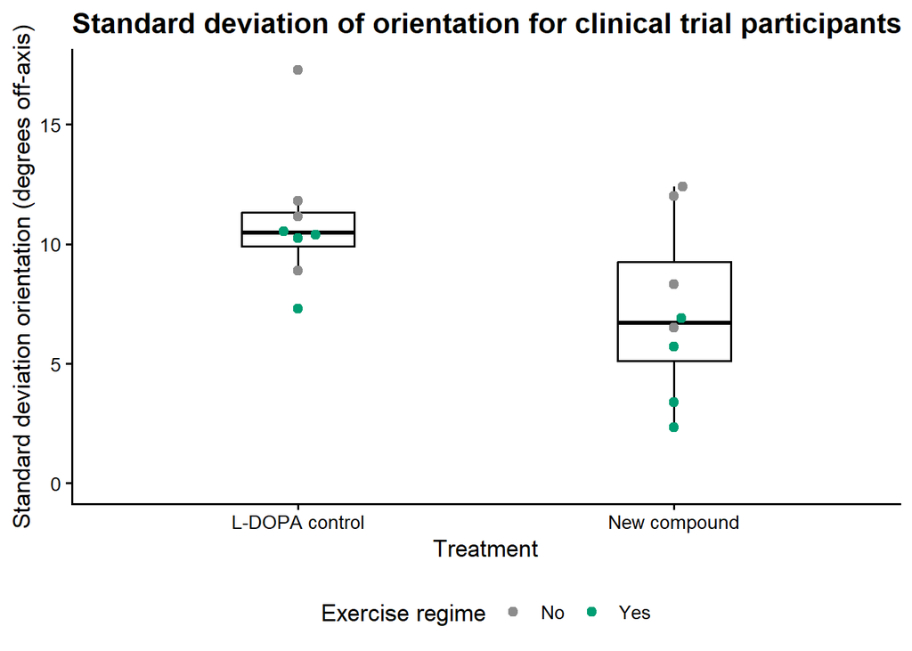

```r
# Make boxplot + beeswarm of standard deviation orientation for patients in each group; colour by exercise group
ggplot(data = gait_summary, aes(x = treatment, y = sd, colour = exercise)) +
  geom_boxplot(width = 0.3, colour = 'black') + # add boxplot
  geom_beeswarm(cex = 2.5, size = 2, preserve.data.axis = TRUE) + # add individual points as beeswarm
  scale_colour_manual(values = c(exercise_colours), labels = c('y' = 'Yes', 'n' = 'No')) +
  scale_y_continuous(limits = c(0, NA)) +
  labs(title = 'Standard deviation of orientation for clinical trial participants',
       x = 'Treatment',
       y = 'Standard deviation orientation (degrees off-axis)',
       colour = 'Exercise regime')
```

From this plot, it appears that the exercise regime is associated with lower sd(orientation) in both treatment groups. This can be tested with a linear model for the relationship between exercise and sd(orientation).

```r
# fit linear model for the effect of exercise regime on sd(orientation)
lm(sd ~ exercise, data = gait_summary) %>%
  summary()
```

```
Call:
lm(formula = sd ~ exercise, data = gait_summary)

Residuals:
    Min      1Q  Median      3Q     Max
-4.7519 -2.2970  0.1614  1.7994  6.2247

Coefficients:
            Estimate Std. Error t value Pr(>|t|)
(Intercept)   11.035      1.141   9.674 1.41e-07 ***
exercisey     -3.937      1.613  -2.440   0.0286 *
---
Signif. codes:  0 '***' 0.001 '**' 0.01 '*' 0.05 '.' 0.1 ' ' 1

Residual standard error: 3.226 on 14 degrees of freedom
Multiple R-squared:  0.2984,    Adjusted R-squared:  0.2483
F-statistic: 5.955 on 1 and 14 DF,  p-value: 0.02857
```

The p-value of 0.029 suggests a significant difference in sd(orientation) between the exercise and no-exercise groups, independently of the effect of treatment. This suggests that the exercise regime leads to lower sd(orientation), or improved balance and gait stability.

We can then test the effect of exercise on the relationship between treatment and sd(orientation). This can be tested by adding exercise as a covariate to the initial linear model.

```r
# fit linear model for the effect of both treatment and exercise regime on sd(orientation)
lm(sd ~ treatment + exercise, data = gait_summary) %>%
  summary()
```

```
Call:
lm(formula = sd ~ treatment + exercise, data = gait_summary)

Residuals:
    Min      1Q  Median      3Q     Max
-4.0367 -1.7827 -0.1733  1.5795  4.3475

Coefficients:
                      Estimate Std. Error t value Pr(>|t|)
(Intercept)             12.912      1.135  11.374 3.96e-08 ***
treatmentNew compound   -3.754      1.311  -2.864   0.0133 *
exercisey               -3.937      1.311  -3.003   0.0102 *
---
Signif. codes:  0 '***' 0.001 '**' 0.01 '*' 0.05 '.' 0.1 ' ' 1

Residual standard error: 2.622 on 13 degrees of freedom
Multiple R-squared:  0.5698,    Adjusted R-squared:  0.5037
F-statistic: 8.611 on 2 and 13 DF,  p-value: 0.004155
```

The p-value of 0.013 for treatment provides evidence for a significant relationship between treatment and sd(orientation) when considering the covariate of exercise. The p-value of 0.0102 for exercise suggests a significant relationship between exercise and sd(orientation), when controlling for treament. These p-values are lower for both predictors than when covariates were not included, suggesting that a model based on treatment and exercise performs better than models only considering one predictor.

#### 7.2.4.3 Investigate the effect of age on the relationship between treatment and gait

Visualise the effect of age on the relationship between treatment and gait smoothness.

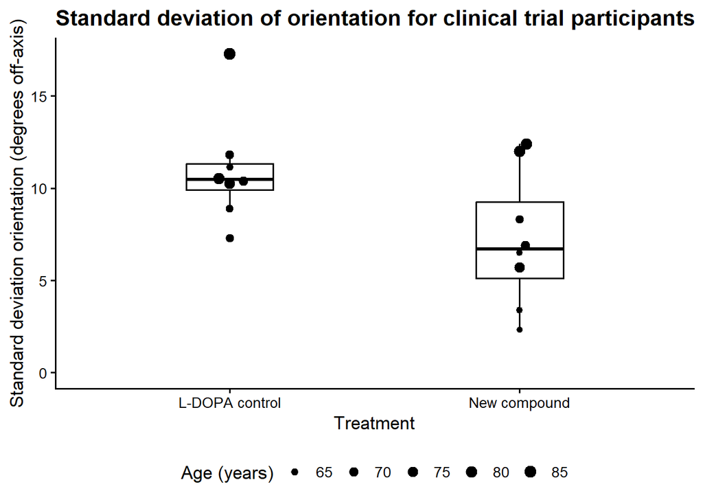

```r
# Make boxplot + beeswarm of standard deviation orientation for patients in each group; size points by age
ggplot(data = gait_summary, aes(x = treatment, y = sd)) +
  geom_boxplot(width = 0.3, colour = 'black') + # add boxplot
  geom_beeswarm(aes(size = age), cex = 2.5, preserve.data.axis = TRUE) + # add individual points as beeswarm
  scale_size_continuous(range = c(1.5, 3.5)) +
  scale_y_continuous(limits = c(0, NA)) +
  labs(title = 'Standard deviation of orientation for clinical trial participants',
       x = 'Treatment',
       y = 'Standard deviation orientation (degrees off-axis)',
       size = 'Age (years)')
```

It appears that younger age may be associated with lower sd(orientation). This is particularly seen in the new compound group, and is not very clear in the L-DOPA control group. This can first be tested with a linear model for the relationship between age and sd(orientation).

```r
# fit a linear model for the effect of age on sd(orientation)
lm(sd ~ age, data = gait_summary) %>%
  summary()
```

```
Call:
lm(formula = sd ~ age, data = gait_summary)

Residuals:
    Min      1Q  Median      3Q     Max
-4.6766 -1.4807 -0.0899  1.6607  4.6043

Coefficients:
            Estimate Std. Error t value Pr(>|t|)
(Intercept) -15.7593     6.9168  -2.278  0.03891 *
age           0.3438     0.0953   3.607  0.00286 **
---
Signif. codes:  0 '***' 0.001 '**' 0.01 '*' 0.05 '.' 0.1 ' ' 1

Residual standard error: 2.773 on 14 degrees of freedom
Multiple R-squared:  0.4817,    Adjusted R-squared:  0.4447
F-statistic: 13.01 on 1 and 14 DF,  p-value: 0.002856
```

The p-value of 0.0029 suggests a highly significant relationship between sd(orientation) and age, independently of the effect of treatment. This makes sense as PD is a progressive disease.

We can then test the effect of age on the relationship between treatment and sd(orientation). This can be tested by adding age as a covariate to the linear model.

```r
# fit a linear model for the effect of both exercise and age on sd(orientation)
lm(sd ~ treatment + age, data = gait_summary) %>%
  summary()
```

```
Call:
lm(formula = sd ~ treatment + age, data = gait_summary)

Residuals:
    Min      1Q  Median      3Q     Max
-3.2515 -1.9409  0.1543  1.9045  2.8012

Coefficients:
                       Estimate Std. Error t value Pr(>|t|)
(Intercept)           -12.39184    5.73382  -2.161  0.04993 *
treatmentNew compound  -3.25267    1.13173  -2.874  0.01304 *
age                     0.31969    0.07779   4.110  0.00123 **
---
Signif. codes:  0 '***' 0.001 '**' 0.01 '*' 0.05 '.' 0.1 ' ' 1

Residual standard error: 2.25 on 13 degrees of freedom
Multiple R-squared:  0.6831,    Adjusted R-squared:  0.6343
F-statistic: 14.01 on 2 and 13 DF,  p-value: 0.0005702
```

The p-value of 0.013 for treatment provides evidence for a significant relationship between treatment and sd(orientation) when considering the covariate of age. The p-value of 0.0012 for age suggests a significant relationship between age and sd(orientation), when controlling for treament. Like before, these p-values are lower than when covariates are not included, again suggesting that including covariates improves the model.

#### 7.2.4.4 Investigate the effect of exercise and age and exercise on relationship between treatment and gait

First, we can visualise the effect of both age and exercise on the relationship between treatment and gait smoothness.

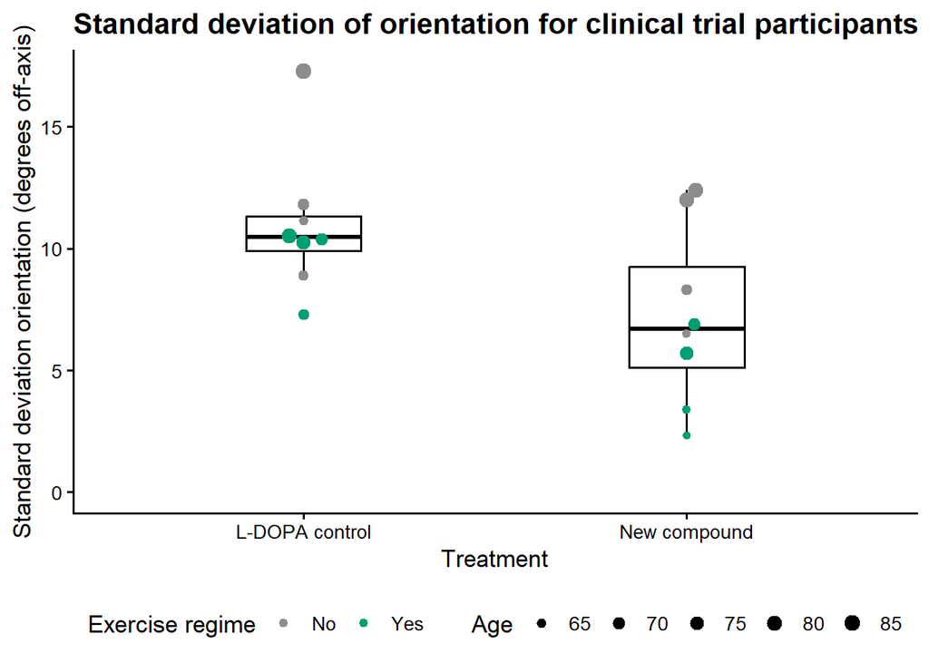

```r
# Make boxplot + beeswarm of standard deviation orientation for patients in each group; colour by exercise group and size points by age
ggplot(data = gait_summary, aes(x = treatment, y = sd, colour = exercise)) +
  geom_boxplot(width = 0.3, colour = 'black') + # add boxplot
  geom_beeswarm(aes(size = age), cex = 2.5, preserve.data.axis = TRUE) + # add individual points as beeswarm
  scale_colour_manual(values = c(exercise_colours), labels = c('y' = 'Yes', 'n' = 'No')) +
  scale_size_continuous(range = c(1.5, 3.5)) +
  scale_y_continuous(limits = c(0, NA)) +
  labs(title = 'Standard deviation of orientation for clinical trial participants',
       x = 'Treatment',
       y = 'Standard deviation orientation (degrees off-axis)',
       colour = 'Exercise regime',
       size = 'Age')
```

Although this plot is quite busy, it shows, like above, that younger and and the exercise regime generally result in lower sd(orientation) in both treatment groups. It also reveals a hidden effect in the L-DOPA control group: while visualising just by age, we could not see any clear effect of age on sd(orientation), but now we see that lower age tends to be associated with lower sd(orientation) within each exercise group.

We can test the effect of both exercise and age on the relationship between treatment and sd(orientation). This can be tested by adding exercise and age as covariates to the linear model.

```r
# fit a linear model for the effect of treatment, exercise, and age on sd(orientation)
lm(sd ~ treatment + exercise + age, data = gait_summary) %>%
  summary()
```

```
Call:
lm(formula = sd ~ treatment + exercise + age, data = gait_summary)

Residuals:
     Min       1Q   Median       3Q      Max
-1.82965 -0.53626 -0.05164  0.53158  1.95463

Coefficients:
                      Estimate Std. Error t value Pr(>|t|)
(Intercept)           -9.01662    2.96919  -3.037   0.0103 *
treatmentNew compound -3.28704    0.57608  -5.706 9.82e-05 ***
exercisey             -3.55270    0.57498  -6.179 4.74e-05 ***
age                    0.29779    0.03975   7.491 7.32e-06 ***
---
Signif. codes:  0 '***' 0.001 '**' 0.01 '*' 0.05 '.' 0.1 ' ' 1

Residual standard error: 1.145 on 12 degrees of freedom
Multiple R-squared:  0.9242,    Adjusted R-squared:  0.9053
F-statistic: 48.78 on 3 and 12 DF,  p-value: 5.373e-07
```

The p-values of 9.82e-05 for treatment, 4.74e-05 for exercise, and 7.32e-06 for age suggest that all three of these variables have a highly significant effect on the outcome of sd(orientation), when controlling for the other two variables. These values are much lower than p-values from linear models using each of the three variables as the sole predictor, or pairs of predictors, suggesting that using all three predictors substantially improves the performance of the linear model. In particular, the linear model using treatment as the sole predictor gave p = 0.039 while the linear model with the two covariates gave p = 9.82e-05 for the treatment predictor; this indicates that age and exercise also influence sd(orientation) and that the inclusion of these covariates significantly improves the linear model’s prediction of sd(orientation).

## 7.3 Questions

The questions asked by this assignment were answered in the above data analysis and are briefly discussed below.

### 7.3.1 Question 1

*Plot each participants’ gait data and describe it using descriptive statistics. Which of these descriptive statistics do you think is most useful for capturing the overall gait smoothness and balance of a participant?*

Plotting the participants’ orientation over time revealed that for each patient, vertical orientation oscillates around zero degrees many times during walking over the observation period. This generally suggests an unsteady gait and poor balance. The spread of orientation in these plots is indicative of the patient’s level of balance and gait stability; smaller variability suggests a more steady gait while large amounts of variability suggest poor balance and instability.

Various descriptive statistics would be appropriate measures of this spread of orientation as a proxy for gait stability and balance. These include mean or median absolute value, SD, RMS, and IQR. While any of these would likely be a suitable proxy, a quick literature search suggested that RMS is commonly used as a meausre of spread in this type of research; since SD and RMS were nearly identical for every patient and SD is more widely used in general, we chose this as our measure of gait smoothness. We confirmed that it is appropriate by showing that the majority of patient’s gait data is roughly symmetrical and does not suggest major departure from normality.

### 7.3.2 Question 2

*Is there a statistically significant difference in gait between participants receiving L-DOPA and the new compound? Ensure that you check your assumptions.*

Plotting patients’ sd(orientation) for each treatment group suggested that the new compound group generally showed lower sd(orientation) than the L-DOPA group, indicating better balance and gait stability.

A Wilcoxon rank-sum test was chosen to test for a statistical difference between the distribution of each treatment group’s sd(orientation). This is because as discussed above, we could not be sure that the assumptions for a standard t-test of a normally distributed outcome variable and equal variance between groups were met.

This test yielded p = 0.083, indicating at most very weak support that there is a difference in the distribution of sd(orientation) between treatment groups. A simple linear model, equivalent to a t-test with equal variances, yielded p = 0.039, providing weak support for a difference in mean sd(orientation) between treatment groups. However, the possible violation of two assumptions of this test mean that the Wilcoxon rank-sum test should be taken as the definitive test for the effect of treatment.

### 7.3.3 Question 3

*Does either of age or the exercise regime affect gait? If so, take this into consideration when investigating the relationship between the treatment and gait.*

Including covariates in a linear model could reveal a stronger association between treatment and sd(orientation). Simple linear regression indicated support for a relationship between sd(orientation) and both available covariates of exercise (p = 0.029) and age (0.0029), independently of treatment. We must still consider that the degree of significance conferred by these tests may be overstated due to violating assumptions of the linear model.

Including these variables as covariates improved the performance of the linear model. In particular, including all three predictors yielded very low p-values for each (9.82e-05 for treatment, 4.74e-05 for exercise, and 7.32e-06 for age). These values are much lower than for any individual or pair of predictors, indicating improved predictions of sd(orientation) by the combined model. This suggests that when controlling for age and exercise, there is a highly significant difference in sd(orientation) between treatment groups, providing preliminary support that the new compound may be more effective in managing balance and gait stability compared to L-DOPA. This may be especially true when combined with the exercise routine, which was also associated with lower sd(orientation) in the model, while younger age also appears to lead to better outcomes. We believe that these p-values in the combined model are so much lower than in the simple regression that highly significant values would still be obtained using a non-parametric model that considers covariates, although this would need to be tested to confirm.

## 7.4 Discussion

While we could not be sure that the normality and equal variance assumptions of a simple linear model were met, the p-values obtained from a simple linear model and a Wilcoxon test were not too different, so we believe that the lower sd(orientation) seen in the new compound group is a true effect when considering age and exercise. While a non-parametric alternative to a linear model may be more appropriate for our data, the best option would be to have a larger sample size of patients, which would improve our ability to test for normality and equal variances of the outcome variable. The small sample size is a limitation of the study design since it both reduces statistical power and may not necessarily represent the population. Another weakness of this analysis is the outcome measure. Poor gait stability is only one possible symptoms of Parkinson’s disease; other symptoms such as tremors, bradykinesia, and non-motor symptoms are also often present. Measuring the effect of the new compound on these other symptoms in further studies may make the results more clinically meaningful.

Overall, this data provides evidence that the new compound can result in greater balance and gait stability compared to the L-DOPA standard of care in Parkinson’s disease, represented by standard deviation of vertical orientation. This effect is especially revealed when considering covariates of age and exercise. Lower age is associated with smoother gait, as might be expected, and completion of the exercise regime is also associated with smoother gait in addition to the treatment. These results provide promising initial data that the new compound may result in better gait stability in Parkinson’s disease compared to the standard of care, especially when combined with an exercise regime.

# 8 Bringing it together/linking between datasets

The following analyses answer the five integration questions using the objects created in the preceding sections. Joining is performed only through the supplied identifiers: `donorid` for participants, Entrez ID for gene-level links, and HGNC symbols as a readable cross-check.

### 8.0.1 Question 1

*Using their unique donor IDs, how many patients appear across all four arms of the study?*

The drug screen used one healthy donor but its dataset does not provide a `donorid`. Therefore, exact four-way donor overlap can only be calculated if the screen donor ID is supplied separately. The code below reports the exact overlap among the three donor-indexed datasets and clearly records the limitation for all four arms.

```r
# Extract donor IDs represented in each donor-indexed study arm.
prs_donors <- prs_final %>% distinct(donorid)
rnaseq_donor_ids <- if ("donorid" %in% names(dge$samples)) {
  as.character(dge$samples$donorid)
} else {
  rownames(dge$samples)
}
rnaseq_donors <- tibble(donorid = rnaseq_donor_ids) %>% distinct(donorid)
gait_donors <- gait_data %>% distinct(donorid)

# Identify donors represented in population genetics, RNA-seq and the trial.
three_arm_donors <- base::Reduce(
  base::intersect,
  list(
    prs_donors$donorid,
    rnaseq_donors$donorid,
    gait_donors$donorid
  )
)

three_arm_donors
```

```
[1] "d003" "d019" "d089" "d136" "d141" "d143" "d260" "d284"
```

```r
length(three_arm_donors)
```

```
[1] 8
```

```r
three_arm_overlap <- tibble(
  comparison = "Population genetics + RNA-seq + clinical trial",
  n_donors = length(three_arm_donors)
)
three_arm_overlap
```

| comparison | n_donors |
| --- | --- |
| Population genetics + RNA-seq + clinical trial | 8 |

```r
three_arm_donors
```

```
[1] "d003" "d019" "d089" "d136" "d141" "d143" "d260" "d284"
```

```r
# A four-way overlap is not identifiable because the drug-screen donor ID is
# absent from plate1, plate_meta and compound_dict.
four_arm_overlap <- tibble(
  comparison = "All four arms",
  n_donors = NA_integer_,
  reason = "Drug-screen donor id was not supplied"
)
four_arm_overlap
```

| comparison | n_donors | reason |
| --- | --- | --- |
| All four arms | NA | Drug-screen donor id was not supplied |

The output gives the number and identities of patients represented in all three donor-indexed arms. The number represented across all four arms cannot be determined from the supplied files because no donor identifier accompanies the drug-screen plate. This should be reported as unavailable rather than treating the drug screen as containing no overlapping donor.

### 8.0.2 Question 2

*Do any variables other than gene expression distinguish the RNA-seq cases from controls?*

MDS coordinates can be joined to PRS and trial metadata to assess whether genetic risk, age, treatment or exercise visually align with the expression-defined sample structure.

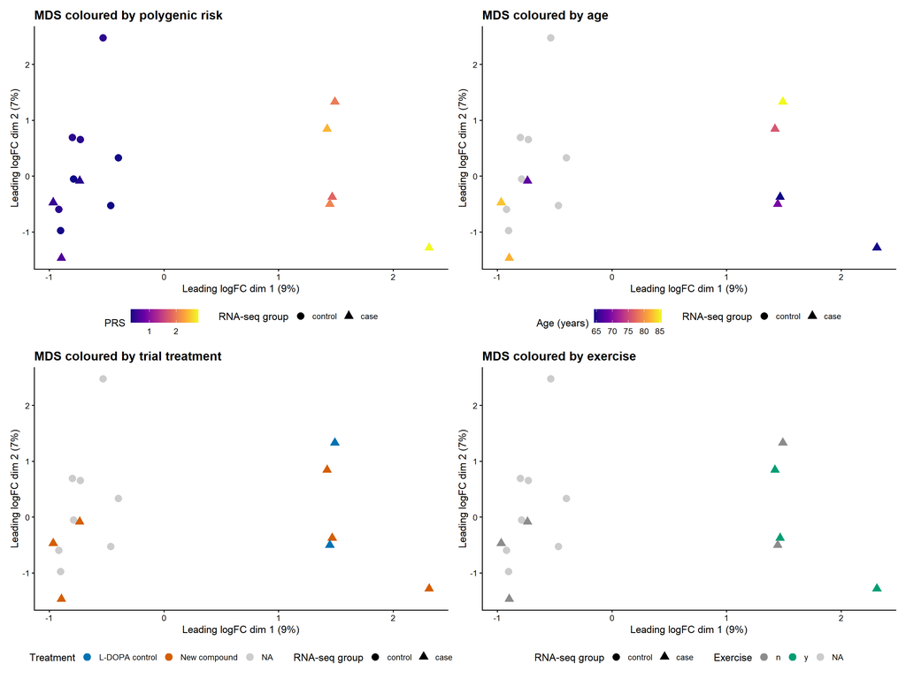

```r
# Obtain the first two MDS coordinates without drawing the base-R plot.
mds_result <- plotMDS(dge, plot = FALSE)

mds_data <- tibble(
  donorid = rnaseq_donor_ids,
  group = dge$samples$group,
  MDS1 = mds_result$x,
  MDS2 = mds_result$y
) %>%
  left_join(prs_final %>% dplyr::select(donorid, PRS), by = "donorid") %>%
  left_join(
    gait_data %>% dplyr::select(donorid, treatment, age, exercise),
    by = "donorid"
  )

dim1_var_explained <- round(mds_result$var.explained[1] * 100)
dim2_var_explained <- round(mds_result$var.explained[2] * 100)

# Disease status remains encoded by point shape in every panel. Continuous PRS
# and age use colour gradients; treatment and exercise use the shared palette.
p_mds_prs <- ggplot(mds_data, aes(MDS1, MDS2, shape = group, colour = PRS)) +
  geom_point(size = 4) +
  scale_colour_viridis_c(option = "C", na.value = "grey80") +
  labs(title = "MDS coloured by polygenic risk",
       x = paste0("Leading logFC dim 1 (", dim1_var_explained, "%)"),
       y = paste0("Leading logFC dim 2 (", dim2_var_explained, "%)"),
       colour = "PRS", shape = "RNA-seq group")

p_mds_age <- ggplot(mds_data, aes(MDS1, MDS2, shape = group, colour = age)) +
  geom_point(size = 4) +
  scale_colour_viridis_c(option = "C", na.value = "grey80") +
  labs(title = "MDS coloured by age",
       x = paste0("Leading logFC dim 1 (", dim1_var_explained, "%)"),
       y = paste0("Leading logFC dim 2 (", dim2_var_explained, "%)"),
       colour = "Age (years)", shape = "RNA-seq group")

p_mds_treatment <- ggplot(mds_data, aes(MDS1, MDS2, shape = group, colour = treatment)) +
  geom_point(size = 4) +
  scale_colour_manual(values = treatment_colours, na.value = "grey80") +
  labs(title = "MDS coloured by trial treatment",
       x = paste0("Leading logFC dim 1 (", dim1_var_explained, "%)"),
       y = paste0("Leading logFC dim 2 (", dim2_var_explained, "%)"),
       colour = "Treatment", shape = "RNA-seq group")

p_mds_exercise <- ggplot(mds_data, aes(MDS1, MDS2, shape = group, colour = exercise)) +
  geom_point(size = 4) +
  scale_colour_manual(values = exercise_colours, na.value = "grey80") +
  labs(title = "MDS coloured by exercise",
       x = paste0("Leading logFC dim 1 (", dim1_var_explained, "%)"),
       y = paste0("Leading logFC dim 2 (", dim2_var_explained, "%)"),
       colour = "Exercise", shape = "RNA-seq group")

(p_mds_prs + p_mds_age) / (p_mds_treatment + p_mds_exercise)
```

```r
# Summarise PRS among RNA-seq cases and controls. Trial variables are available
# only for RNA-seq donors who also participated in the clinical trial.
mds_data %>%
  group_by(group) %>%
  summarise(
    n = n(),
    n_with_prs = sum(!is.na(PRS)),
    mean_prs = mean(PRS, na.rm = TRUE),
    median_prs = median(PRS, na.rm = TRUE),
    n_in_trial = sum(!is.na(treatment)),
    .groups = "drop"
  )
```

| group | n | n_with_prs | mean_prs | median_prs | n_in_trial |
| --- | --- | --- | --- | --- | --- |
| control | 8 | 8 | 0.365625 | 0.3615 | 0 |
| case | 8 | 8 | 1.571500 | 1.8990 | 8 |

Among cases, PRS and age show visible gradients across the MDS space: the case furthest to the right has comparatively high PRS and is younger, while cases at lower MDS1 values tend to have lower PRS and are older. However, these patterns are based on few participants and should be considered exploratory.

### 8.0.3 Question 3

*Are any of the gene targets of hit compounds from the drug screen, differentially expressed in RNA-seq? Which GO terms are they associated with and what might this tell you about the pathology of PD?*

This analysis intersects statistically significant drug-screen targets with genes meeting the RNA-seq FDR threshold, then attaches the supplied GO annotations.

```r
# Retain only FDR-significant positive screening hits and their supplied targets.
hit_targets <- compound_tests %>%
  filter(hit) %>%
  transmute(
    compound_id,
    target_entrez_id = as.integer(target_enzyme),
    target_gene = hgnc_symbol,
    mechanism = action,
    drug_effect_rlu = effect_rlu,
    drug_fdr = fdr_bh
  )

# Keep RNA-seq genes passing BH FDR and label their direction in PD.
de_targets <- top_tibble %>%
  filter(adj.P.Val < 0.05) %>%
  transmute(
    target_entrez_id = as.integer(genes),
    rnaseq_gene = SYMBOL,
    logFC,
    rnaseq_fdr = adj.P.Val,
    expression_direction = if_else(logFC > 0, "Higher in PD", "Lower in PD")
  )

# Join by Entrez ID, then attach all supplied GO terms for overlapping targets.
hit_de_overlap <- hit_targets %>%
  inner_join(de_targets, by = "target_entrez_id") %>%
  left_join(
    gene_ontology %>%
      transmute(target_entrez_id = as.integer(entrezgene_id), go_id, go_term = desc),
    by = "target_entrez_id"
  ) %>%
  arrange(drug_fdr, rnaseq_fdr, target_gene, go_term)

hit_de_overlap
```

| compound_id | target_entrez_id | target_gene | mechanism | drug_effect_rlu | drug_fdr | rnaseq_gene | logFC | rnaseq_fdr | expression_direction | go_id | go_term |
| --- | --- | --- | --- | --- | --- | --- | --- | --- | --- | --- | --- |
| cmpd_5631 | 9215 | LARGE1 | agonist | 197.50 | 0.00134644 | LARGE1 | -3.959135 | 1.833278e-03 | Lower in PD | GO:0007268 | Synaptic transmission |
| cmpd_5706 | 6014 | RIT2 | agonist | 201.75 | 0.02465230 | RIT2 | -4.377185 | 2.013154e-05 | Lower in PD | GO:0007268 | Synaptic transmission |
| cmpd_5986 | 4040 | LRP6 | agonist | 177.25 | 0.03161045 | LRP6 | -3.383139 | 1.741777e-03 | Lower in PD | GO:0007268 | Synaptic transmission |
| cmpd_4996 | 5594 | MAPK1 | agonist | 186.00 | 0.04767036 | MAPK1 | -1.751070 | 5.673801e-05 | Lower in PD | GO:0007268 | Synaptic transmission |

```r
if (nrow(hit_targets) == 0) {
  cat("**Answer.** No compound passed the pre-specified drug-screen FDR threshold, so there are no statistically supported hit targets to test for RNA-seq overlap. Nominal compounds should not be used to make mechanistic claims.")
} else if (nrow(hit_de_overlap) == 0) {
  cat("**Answer.** None of the statistically supported drug-screen targets were differentially expressed at RNA-seq FDR < 0.05. This does not exclude functional involvement because drug activity can alter protein function without changing transcript abundance.")
} else {
  overlap_genes <- hit_de_overlap %>% distinct(target_gene) %>% pull(target_gene)
  overlap_terms <- hit_de_overlap %>% filter(!is.na(go_term)) %>% distinct(go_term) %>% pull(go_term)
  cat("**Answer.** Differentially expressed drug-hit targets were: ",
      paste(overlap_genes, collapse = ", "), ". Their supplied GO terms were: ",
      ifelse(length(overlap_terms) == 0, "none available", paste(overlap_terms, collapse = ", ")),
      ". The direction of expression and the compound mechanism should be interpreted together; overlap prioritises a pathway for validation but does not prove target-level causation.", sep = "")
}
```

**Answer.** Differentially expressed drug-hit targets were: LARGE1, RIT2, LRP6, MAPK1. Their supplied GO terms were: Synaptic transmission. The direction of expression and the compound mechanism should be interpreted together; overlap prioritises a pathway for validation but does not prove target-level causation.

Yes. Four targets of compounds that increased luminescence in the drug screen were also significantly differentially expressed in PD-derived neurons: LARGE1, RIT2, LRP6, and MAPK1. All four were expressed at lower levels in PD neurons than in healthy control neurons after multiple-testing correction.

These overlapping targets were annotated with the supplied GO term “synaptic transmission.” Together, the results suggest that PD neurons may have reduced expression of genes involved in neuronal signalling and synaptic function. Notably, the corresponding agonist compounds increased luminescence following MPP exposure, so activating these targets may partially compensate for disease-associated loss of function or support neuronal survival under mitochondrial and oxidative stress.

However, this is a prioritisation result rather than proof of mechanism. The drug screen used technical quadruplicates from one healthy donor, while RNA-seq measured transcript abundance in a separate cohort of PD and control neurons. Drug-induced neuroprotection could result from direct target activation, downstream pathway effects, or off-target activity and validation should therefore include independent donors, dose-response experiments, protein-level target assessment, and an orthogonal viability assay.

### 8.0.4 Question 4

*Is there any relationship between the PRS and gait of patients in the clinical trial?*

Standard deviation of vertical orientation is retained as the gait-smoothness outcome from the clinical-trial section. The analysis shows the raw relationship and then adjusts for age, exercise and treatment because these variables were investigated as potential covariates.

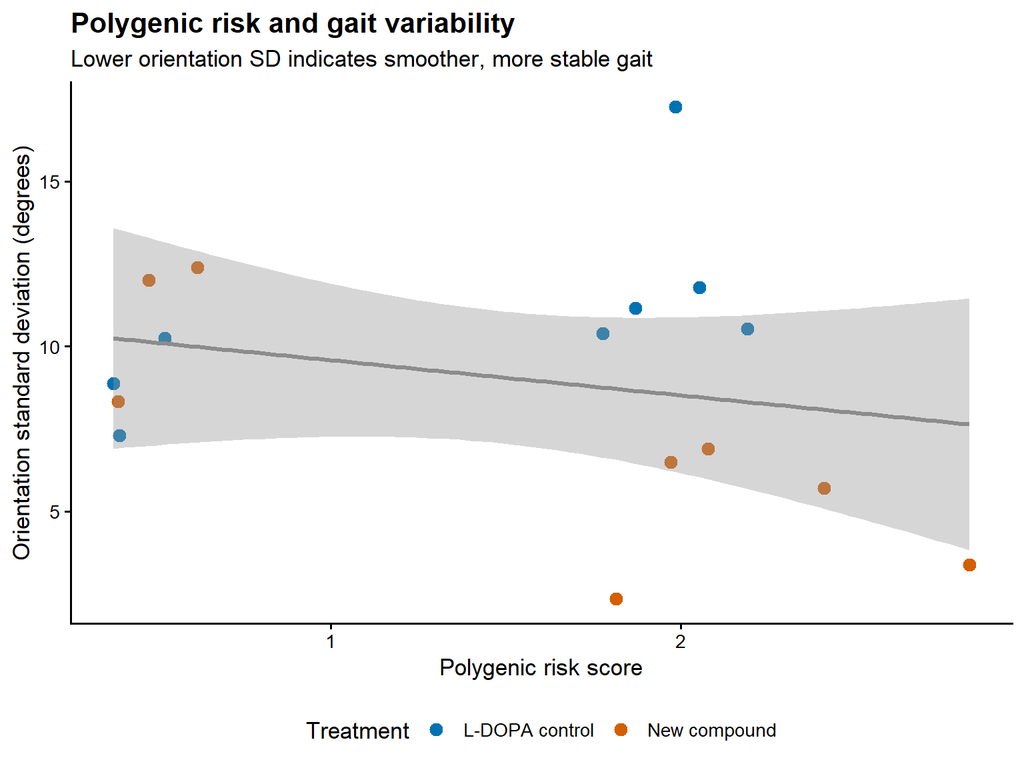

```r
prs_gait <- gait_summary %>%
  inner_join(prs_final %>% dplyr::select(donorid, PRS), by = "donorid")

# Plot every overlapping participant; treatment uses the shared colour scheme.
ggplot(prs_gait, aes(PRS, sd, colour = treatment)) +
  geom_point(size = 3) +
  geom_smooth(method = "lm", se = TRUE, colour = neutral_colour) +
  scale_colour_manual(values = treatment_colours) +
  labs(
    title = "Polygenic risk and gait variability",
    subtitle = "Lower orientation SD indicates smoother, more stable gait",
    x = "Polygenic risk score",
    y = "Orientation standard deviation (degrees)",
    colour = "Treatment"
  )
```

```r
# Spearman correlation provides an unadjusted monotonic association without
# assuming that PRS and gait SD are jointly normally distributed.
prs_gait_spearman <- cor.test(
  prs_gait$PRS,
  prs_gait$sd,
  method = "spearman",
  exact = FALSE
)
prs_gait_spearman
```

```
    Spearman's rank correlation rho

data:  prs_gait$PRS and prs_gait$sd
S = 822, p-value = 0.4377
alternative hypothesis: true rho is not equal to 0
sample estimates:
       rho
-0.2088235
```

```r
# Adjust for the trial variables already assessed in the gait analysis.
prs_gait_model <- lm(sd ~ PRS + treatment + age + exercise, data = prs_gait)
summary(prs_gait_model)
```

```
Call:
lm(formula = sd ~ PRS + treatment + age + exercise, data = prs_gait)

Residuals:
     Min       1Q   Median       3Q      Max
-1.63640 -0.63069  0.02304  0.58857  1.90205

Coefficients:
                      Estimate Std. Error t value Pr(>|t|)
(Intercept)           -9.47160    3.14089  -3.016 0.011748 *
PRS                    0.23139    0.38065   0.608 0.555614
treatmentNew compound -3.32370    0.59490  -5.587 0.000163 ***
age                    0.30041    0.04107   7.315 1.51e-05 ***
exercisey             -3.67275    0.62285  -5.897 0.000104 ***
---
Signif. codes:  0 '***' 0.001 '**' 0.01 '*' 0.05 '.' 0.1 ' ' 1

Residual standard error: 1.177 on 11 degrees of freedom
Multiple R-squared:  0.9267,    Adjusted R-squared:    0.9
F-statistic: 34.75 on 4 and 11 DF,  p-value: 3.499e-06
```

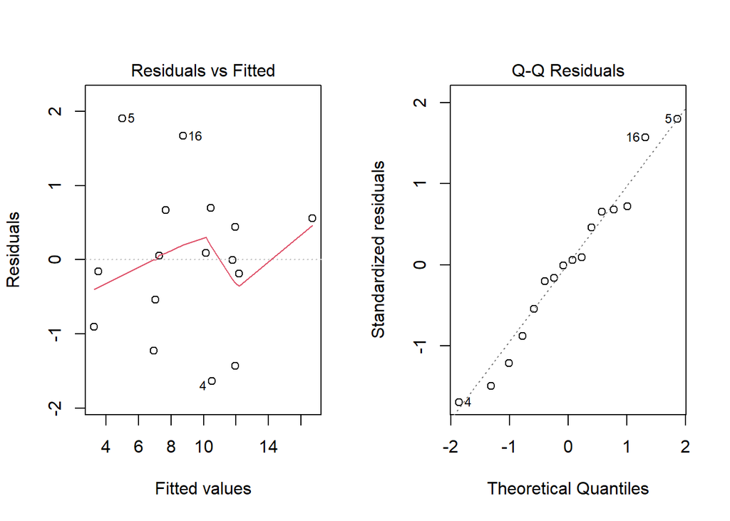

```r
# Check linear-model assumptions with residual diagnostic plots.
par(mfrow = c(1, 2))
plot(prs_gait_model, which = 1)
plot(prs_gait_model, which = 2)
```

```r
par(mfrow = c(1, 1))
```

The Spearman coefficient describes the unadjusted direction and strength of association. In the adjusted model, the PRS coefficient estimates the expected change in gait SD per one-unit increase in PRS while holding treatment, age and exercise constant. Because the clinical trial contains only 16 participants, estimates are imprecise and the model may be overfitted; effect size, uncertainty and diagnostic plots should be considered alongside the p-value.

### 8.0.5 Question 5

*In a paragraph, summarise your findings and suggest directions for future research.*

```r
n_three_arm <- length(three_arm_donors)
n_overlap_targets <- n_distinct(hit_de_overlap$target_gene)
rho <- unname(prs_gait_spearman$estimate)
rho_p <- prs_gait_spearman$p.value

cat(
  "Across the donor-indexed datasets, ", n_three_arm,
  " participant(s) were represented in population genetics, RNA-seq and the clinical trial; exact four-arm overlap could not be determined because the drug-screen donor ID was not supplied. PD cases had higher PRS than controls in the population analysis, while RNA-seq showed case-associated expression changes involving autophagy and synaptic-transmission genes, with some heterogeneity among cases. There were ",
  n_overlap_targets, " differentially expressed target gene(s) among FDR-significant drug-screen hits. Among trial participants with PRS data, the unadjusted PRS–gait association was Spearman rho = ",
  round(rho, 2), " (p = ", format.pval(rho_p, digits = 3),
  "). These integrated findings are exploratory because the RNA-seq and trial cohorts are small and the drug screen contains technical replicates from one healthy donor. Future work should validate compounds across independent donors and dose ranges, confirm viability with orthogonal assays, measure target engagement at RNA and protein levels, and test PRS–expression–gait relationships in a larger cohort with pre-specified multivariable models.",
  sep = ""
)
```

Across the donor-indexed datasets, 8 participant(s) were represented in population genetics, RNA-seq and the clinical trial; exact four-arm overlap could not be determined because the drug-screen donor ID was not supplied. PD cases had higher PRS than controls in the population analysis, while RNA-seq showed case-associated expression changes involving autophagy and synaptic-transmission genes, with some heterogeneity among cases. There were 4 differentially expressed target gene(s) among FDR-significant drug-screen hits. Among trial participants with PRS data, the unadjusted PRS–gait association was Spearman rho = -0.21 (p = 0.438). These integrated findings are exploratory because the RNA-seq and trial cohorts are small and the drug screen contains technical replicates from one healthy donor. Future work should validate compounds across independent donors and dose ranges, confirm viability with orthogonal assays, measure target engagement at RNA and protein levels, and test PRS–expression–gait relationships in a larger cohort with pre-specified multivariable models.

Across the donor-indexed datasets, eight participants were represented in the population genetics, RNA-seq and clinical-trial arms; however, exact overlap across all four arms could not be determined because the drug-screen donor ID was unavailable. PD cases had higher polygenic risk scores than controls, while RNA-seq identified PD-associated expression differences involving autophagy- and synaptic-transmission-related genes, with some heterogeneity among cases. Four targets of FDR-significant drug-screen hits were also differentially expressed in the RNA-seq dataset, prioritising these genes and pathways for further investigation. In the clinical-trial subset with PRS data, PRS was not significantly associated with gait variability (Spearman rho = -0.21, p = 0.438). These results are exploratory because the RNA-seq and clinical-trial cohorts were small, and the drug screen comprised technical replicates from a single healthy donor. Future studies should validate promising compounds across independent donor-derived neuronal cultures and dose ranges, confirm neuroprotection using orthogonal viability and functional assays, assess target engagement at RNA and protein levels, and evaluate relationships among genetic risk, gene expression and clinical outcomes in larger, pre-specified multivariable cohorts.

```r
# Save all workspace objects in case it is modified
save.image(file = "BIOL90042_workspace.RData")

# Restore later
load("BIOL90042_workspace.RData")
```